# 15 Régression linéaire simple: Inférences

- Montrer tout le code
- Cacher tout le code

Auteur

Affiliation

Daniel Coulombe

Institut des Sciences, Technologies et Études Avancées d’Haïti (ISTEAH)

Date

25/03/2024

Au chapitre 4, plusieurs indices mesurant l’importance d’une relation entre deux variables ont été présentés. Lorsque cette relation existe, il devient possible de prédire la valeur de l’une (variable dépendante) à partir de l’autre (variable indépendante). Dans ce chapitre, nous examinons les détails des procédures permettant une telle prédiction lorsque la variable dépendante est quantitative. Il s’agit d’une première étape vers l’élaboration de modèles plus complexes qui feront l’objet de chapitres ultérieurs, mais qui partagent les mêmes objectifs:

- expliquer une variable dépendante, c’est-à-dire en déterminer les sources d’influence et en quantifiant leur importance respective;
- prédire la variable dépendante à partir d’une ou plusieurs variables indépendantes.

Mais dans un premier temps, revenons sur la notion de corrélation, et plus spécifiquement sur les inférences la concernant.

## 15.1 Inférences sur les corrélations

Plusieurs procédures inférentielles s’appliquent aux corrélations, de la même manière que pour les autres statistiques. Plusieurs indices quantifiant la relation entre variables existent, et chacun d’eux fait appel à des procédures qui peuvent différer. Cependant, le principe général demeure constant. Nous limiterons donc la discussion au coefficient de corrélation de Bravais-Pearson.

### 15.1.1 Approche empirique

La distribution d’échantillonnage d’une corrélation est essentielle pour toute inférence concernant cet indice. On pourrait obtenir cette distribution en tirant un grand nombre d’échantillons d’une certaine taille, d’une population normale bivariée où la corrélation $r_{xy}$ est connue. Pour chacun des échantillons, on calcule la corrélation entre les deux variables, pour finalement en établir la distribution.

Le code R suivant applique cette stratégie. Spécifiquement, 100,000 échantillons de taille $n = 50$ sont tirés aléatoirement d’une population normale bivariée où $r_{xy}=0$. La distribution des corrélations observées pour les différents échantillons est affichée à la figure Figure 15.1:

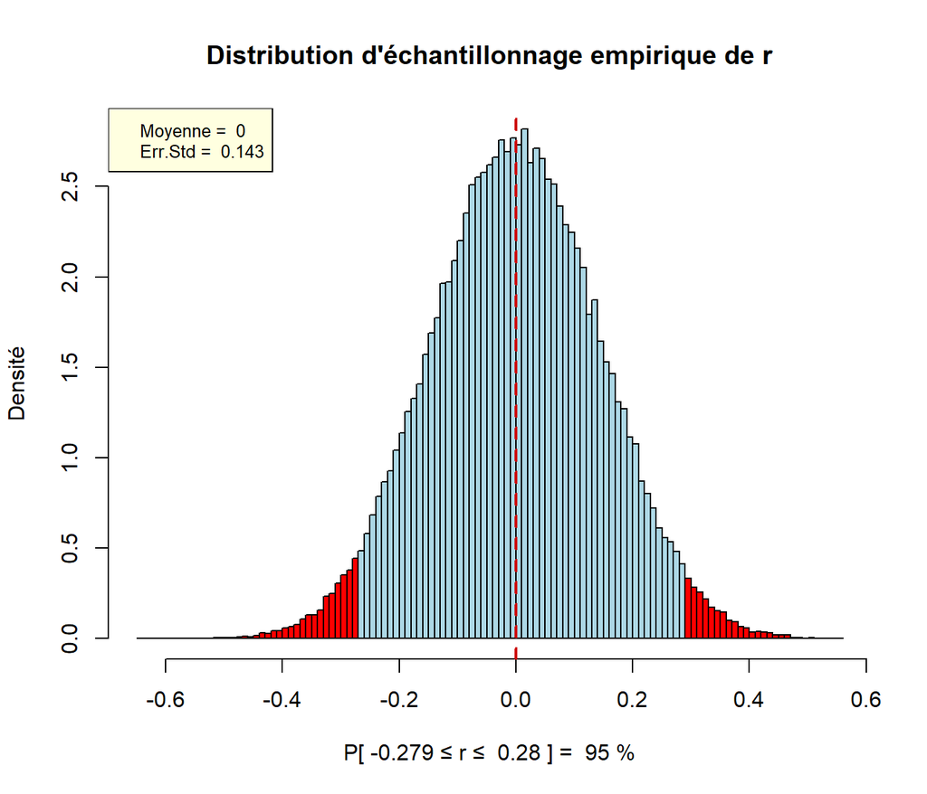

Figure 15.1: Distribution d’échantillonnage d’une corrélation ($\rho = 0$).

```r
nreps <- 100000
r <- 0.0
n <- 50

SDr <- replicate(nreps,
                 cor(
                 MASS::mvrnorm(n = n,
                     mu = c(0, 0),
                     Sigma = matrix(c(1, r, r, 1),
                                    nrow = 2))
                 )[1, 2])

conf <- 95
low = (1-conf/100)/2
upp = ((1-conf/100)/2)+(conf/100)
LL  = round(quantile(SDr, low), 3)
UL  = round(quantile(SDr, upp), 3)

gr1 <- hist(SDr,
            breaks = "FD",
            plot = FALSE)
cuts <- cut(gr1$breaks, c(-Inf, LL, UL, Inf))
plot(gr1,
     main = "Distribution d'échantillonnage empirique de r",
     col = c("red", "lightblue", "red")[cuts],
     freq=FALSE,
     xlab=paste("P[", LL,"\u2264 r \u2264 ",UL,"] = ",conf, "%"),
     ylab = "Densité",
     cex=0.4)
abline(v=mean(SDr), lty=2, lwd=2, col="#CC0000")
txt1 <- paste("Moyenne = ", round(mean(SDr), 3))
txt2 <- paste("Err.Std = ", round(sd(SDr), 3))
legend("topleft",
       legend = c(txt1, txt2),
       lty = 0:0,
       cex = 0.8,
       bg = "lightyellow")
```

$$\sigma_{r_{xy}}=\sqrt{\frac{1-r_{xy}^2}{n-2}}\approx \sqrt{\frac{1-0^2}{50-2}}\approx 0.144$$

La portion centrale de la distribution rassemble les valeurs probables des corrélations observées pour des échantillons. Dans le cas présent, 95% des corrélations se trouvent comprises entre -0.279 et 0.28, ce qui constitue l’intervalle des valeurs probables, obtenu de manière empirique (par simulation). Ainsi, en tirant un échantillon de $n=50$ observations d’une population normalement distribuée, on peut s’attendre à obtenir des corrélations comprises entre -0.28 et +0.28, la distribution d’échantillonnage étant au moins approximativement normale. La probabilité que ce soit le cas est égale à 0.95.

L’implication de cette observation est que si, dans un test d’hypothèse pour une corrélation, $H_0$ propose une corrélation nulle ($H_0:\rho=0$), il sera possible d’utiliser la distribution normale (grands échantillons) ou la distribution de Student (petits échantillons) pour obtenir les probabilités nécessaires à la conclusion du test.

Malheureusement, la normalité que l’on peut voir dans ce cas précis ne tient plus la route lorsque la corrélation prend des valeurs plus élevées (en valeurs absolues). En effet, la distribution des corrélation est limitée par $r=1.0$ et $r=-1.0$, de sorte que pour des coefficients de corrélation élevés, la distribution est nécessairement asymétrique. Lorsque la corrélation est positive, la distribution d’échantillonnage de $r$ est négativement asymétrique, et lorsque la corrélation est négative, elle est positivement asymétrique. En conséquence, les distributions normale et de Student ne sont plus appropriées. La figure Figure 15.2 illustre ce point, présentant les distributions d’échantillonnage de $r_{xy}$ obtenues à partir de 100,000 échantillons de taille 50, tous tirés d’une population où $\rho = \pm 0.70$.

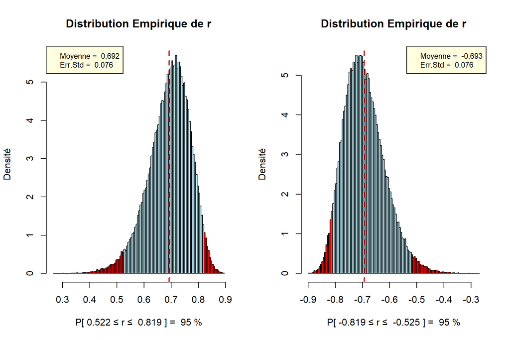

Figure 15.2: Distribution Empirique de Rxy ($\rho=\pm 0.7$)

```r
par(mfrow=c(1,2))
R_CI(r=0.70, n=50, nrep=100000, conf=95)
R_CI(r=-0.70, n=50, nrep=100000, conf=95)
```

Pour contourner ce problème, Fisher (1915) a proposé une transformation permettant de rétablir la normalité de la distribution d’échantillonnage, lorsqu’une corrélation existe entre les variables X et Y, au niveau de la population.

### 15.1.2 Transformation de Fisher

La transformation de Fisher permet de convertir une corrélation en score $z$ en utilisant l’équation Équation 15.1) :

$$z=0.5~ ln\left(\frac{1+r}{1-r} \right) \tag{15.1}$$

… et de renverser cette transformation, utilisant l’équation Équation 15.2:

$$r=\frac{e^{2z}-1}{e^{2z}+1} \tag{15.2}$$

Par exemple, pour $r=0.6$, on trouve:

$$z=0.5~ ln\left(\frac{1+0.6}{1-0.6} \right) =0.5~ln(4)=0.693$$

… et pour retrouver $r$:

$$r=\frac{e^{2(0.693)}-1}{e^{2(0.693)}+1}=\frac{4-1}{4+1}=0.6$$

Sous R, les fonctions **r2z()** et **z2r()**, disponibles dans la librairie **isteahMAT104** permettent la conversion $r \rightarrow z$ et de $z \rightarrow r$.

Pour $r=0.6$, on obtient:

```r
r <- 0.6
z <- r2z(r)
cat("Pour r = ", r, "z = ", z)
```

```
#> Pour r =  0.6 z =  0.6931472
```

```r
r <- z2r(z)
cat("Pour z = ", z, "r = ", r)
```

```
#> Pour z =  0.6931472 r =  0.6
```

Contrairement à la distribution de $r$ pour $\rho \ne 0$, la distribution de $z$ est normale, ce qui rendra possible les procédures inférentielles présentées dans les paragraphes suivants. La figure Figure 15.3 nous rassure sur ce point, pour des corrélations $r=\pm0.7$ La simulation est effectuée à l’aide de la fonction **Z_CI()** de la librairie **isteahMAT104**.

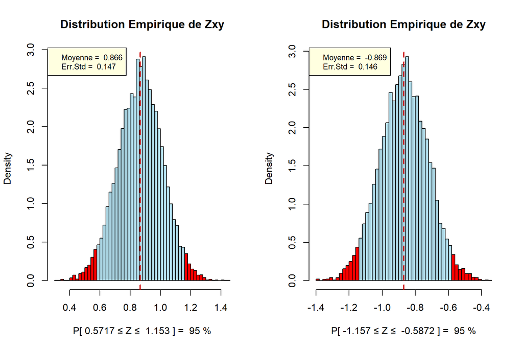

Figure 15.3: Distribution Empirique de Rxy ($\rho=\pm 0.7$), les corrélations étant soumises à la transformation de Fisher.

```r
par(mfrow=c(1,2))
res1 <- Z_CI(r=0.7, n=50, nrep=10000, conf=95)
res2 <- Z_CI(r=-0.70, n=50, nrep=10000, conf=95)
```

On note que cette fois une distribution symétrique, cette symétrie persistant peu importe la valeur de $\rho$. Les moyennes de ces distributions sont des valeurs de Z, que l’on peut transformer en $r$:

```r
r <- z2r(0.867)
cat("Pour z = 0.867, r = ", r)
```

```
#> Pour z = 0.867, r =  0.6998467
```

```r
r <- z2r(-0.867)
cat("Pour z = -0.867, r = ", r)
```

```
#> Pour z = -0.867, r =  -0.6998467
```

### 15.1.3 Ré-échantillonnage

Tirer un grand nombre d’échantillons d’une population n’est pas une activité réalisable en réalité. Par contre, le ré-échantillonnage permet d’obtenir la distribution d’échantillonnage d’une corrélation permettant les exercices d’inférence concernant cet indice.

Le processus de ré-échantillonnage se déroule comme suit:  
1. On tire un échantillon de taille $n$ d’une population, et on calcule $r_{xy}$;  
2. Utilisant cet échantillon initial, on forme un nouvel échantillon de même taille, aléatoire et **avec remise**, et on calcule $r_{xy}$  
3. On répète (2) un très grand nombre de fois, pour obtenir un ensemble de $k$ $r_{xy}$  
4. On forme la distribution des $r_{xy}$ observés et on en établit les caractéristiques.

Pour illustrer la procédure, considérons les données simulées suivantes, pour un échantillon de $n=50$. Les données générées sont deux variables centrées et réduites (X et Y). Les 6 premières observations sont affichées ci-dessous:

```r
r <- 0.6
n <- 50

XY <- MASS::mvrnorm(n = n,
                     mu = c(0, 0),
                     Sigma = matrix(c(1, r, r, 1),
                                    nrow = 2))
colnames(XY) <- c("X", "Y")
head(XY)
```

```
#>                X          Y
#> [1,]  2.24223697  0.3959478
#> [2,]  1.21084028 -0.6641238
#> [3,] -0.20965716 -0.0779537
#> [4,]  0.03717134 -0.7327874
#> [5,] -0.63841426 -1.2137307
#> [6,] -0.24495951  0.8511121
```

La corrélation entre ces variables est $r_{XY}=0.701$.

La figure Figure 15.4 représente la distribution de ré-échantillonnage des corrélations impliquant 100,000 itérations:

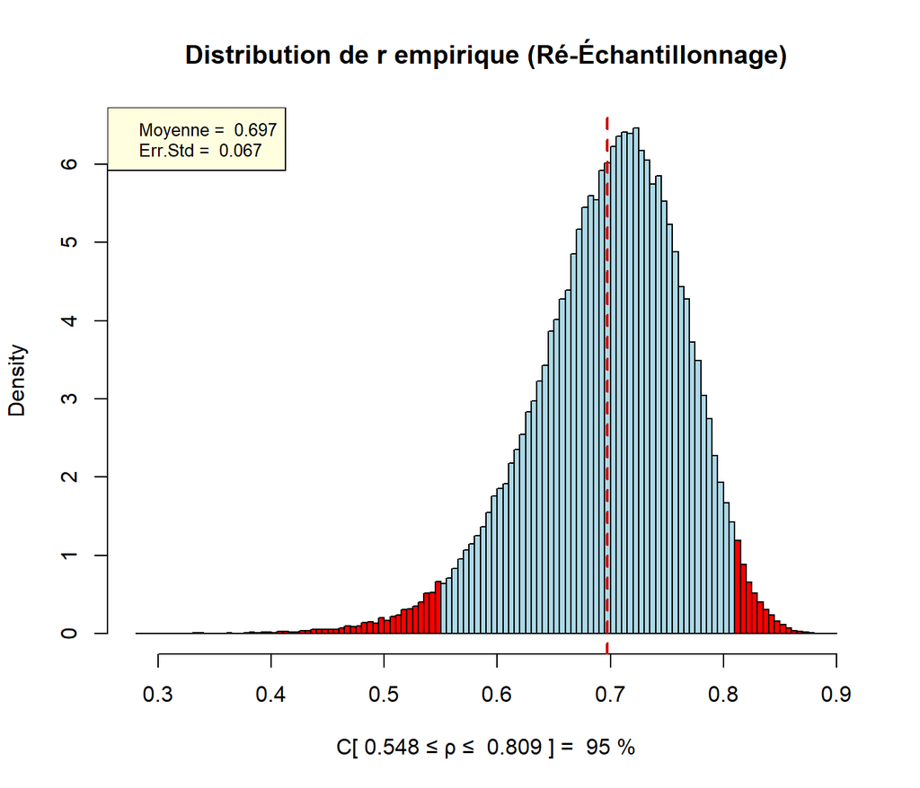

Figure 15.4: Distribution de ré-échantillonnage d’une corrélation ($\rho = 0.6$).

```r
b3 <- boot(XY,
           statistic = function(XY, i) {
             cor(XY[i, "X"], XY[i, "Y"], method='pearson')
  },
  R = 100000
)

b3CI <- boot.ci(b3,
                type = "perc")

LL <- b3CI$percent[4]
UL <- b3CI$percent[5]

gr1 <- hist(b3$t,
              breaks = "FD",
              plot = FALSE)
  cuts <- cut(gr1$breaks, c(-Inf, LL, UL, Inf))
  plot(gr1,
       main = "Distribution de r empirique (Ré-Échantillonnage)",
       col = c("red", "lightblue", "red")[cuts],
       freq = FALSE,
       xlab = paste("C[", round(LL, 3),"\u2264 \u03C1 \u2264 ", round(UL, 3),"] = ",conf, "%"), cex=0.4)
  abline(v=mean(b3$t), lty=2, lwd=2, col="#CC0000")
  txt1 <- paste("Moyenne = ", round(mean(b3$t), 3))
  txt2 <- paste("Err.Std = ", round(sd(b3$t), 3))
  legend("topleft",
         legend = c(txt1, txt2),
         lty = 0:0,
         cex = 0.8,
         bg = "lightyellow")
```

La distribution obtenue diffère de celle représentée à la figure Figure 15.1 en ce qu’elle est formée de corrélations obtenues en ré-échantillonnant l’échantillon initial, plutôt qu’en échantillonnant un grand nombre de fois une population. De ce fait, la moyenne de la distribution correspond à la corrélation observée au niveau de l’**échantillon**, plutôt que la corrélation réelle au niveau de la population. Dans ce cas, il est possible de formuler un intervalle de **confiance**, plutôt qu’un intervalle de **valeurs probables**.

Si l’hypothèse soumise au test propose une corrélation dont la valeur est l’une comprise dans l’intervalle de confiance, on sera amené à retenir $H_0$. Dans le cas contraire, on pourra rejeter cette hypothèse au niveau de confiance $100(1-\alpha)\%$.

Par exemple, s’il est proposé que $H_0:\rho_{XY}=0.45$, l’analyste sera amené à rejeter cette hypothèse, puisque cette corrélation se trouve à l’extérieur de l’intervalle $[0.548, 0.809]$. Elle fait partie des valeurs dont la probabilité est faible (zone rougerouge dans le diagramme.).

#### 15.1.3.1 Inférences concernant une corrélation: approche analytique

L’estimation d’une corrélation nécessite l’application de la transformation de Fisher de manière à s’assurer de la normalité de la distribution d’échantillonnage des corrélations. À titre d’exemple, supposons que la corrélation observée pour un échantillon de $n=56$ sujets, entre la performance en Sciences et la performance en Mathématiques est $r=0.68$. Appliquant la transformation de Fisher sur cette corrélation, on obtient:

```r
z <- r2z(0.68)
cat("z = ", z)
```

```
#> z =  0.829114
```

et la distribution d’échantillonnage de cette quantité est présentée dans la figure Figure 15.5.

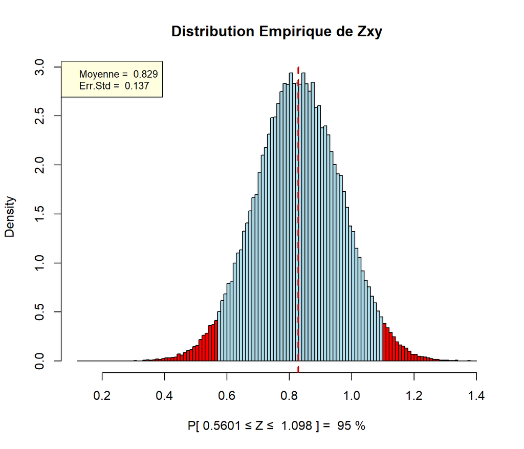

Figure 15.5: Distribution d’échantillonnage de Zxy ($\rho=0.68$)

```r
zst <- Z_CI(r=0.68, n=56)
```

Cette distribution est normale, avec une moyenne $\mu_z=0.8292$ et une erreur-standard $\sigma_z=0.1373$. Cette dernière quantité est approximativement égale à :

$$\sigma_z=\frac{1}{\sqrt{n-3}}=\frac{1}{\sqrt{56-3}}=0.13736$$
À ce stade, nous disponsons de tous les éléments nécessaires à la formulation d’inférences concernant une corrélation.

### 15.1.4 Test d’hypothèse concernant une corrélation

Dans un test d’hypothèse portant sur une corrélation, $H_0$ peut proposer une corrélation nulle, ou une corrélation égale à une valeur donnée:

$$H_0:\rho=0$$
$$H_0:\rho=0.60$$

#### 15.1.4.1 Inférence, supposant $\rho = 0$:

On sait que si la corrélation au niveau de la population est nulle, la distribution d’échantillonnage de $r$ sera au moins approximativement normale. Dans ce cas, on pourra utiliser un test *t* défini par l’équation Équation 15.3.

$$t=\frac{r \sqrt{n-2}}{\sqrt{1-r^2}},~~~~dl=n-2 \tag{15.3}$$

Par exemple, la corrélation entre les scores obtenus par un échantillon de 50 étudiants de Lycée dans un examen de Sciences et un examen de Mathématiques est $r=0.47$. Peut-on affirmer que cette corrélation est significativement différente de 0, au niveau de la population?

Pour répondre à cette question, posons:

$$H_0:\rho=0$$
$$H_1:\rho \ne 0$$
Appliquant l’équation Équation 15.3, on calcule:

$$t=\frac{0.47 \sqrt{50-2}}{\sqrt{1-0.47^2}} =\frac{3.256}{0.883}=3.687,~~~~dl=50-2=48$$

Si $H_0$ est vraie, la probabilité d’obtenir un tel $t$ ou une valeur plus extrême est donnée par la distribution de Student pour $n-2 = 50-2=48$ degrés de liberté:

```r
p <- pt(3.687, 48, lower.tail=FALSE)
cat("p(t > 3.687) = ", round(p, 5))
```

```
#> p(t > 3.687) =  0.00029
```

Puisque cette probabilité est inférieure au niveau de signification $\alpha=0.05$, on rejette $H_0$, et on conclut qu’il y a évidence d’une corrélation entre la performance en Mathématiques et la performance en Sciences. Cette corrélation est dite *statistiquement significative*. Notons que cette conclusion ne fournit aucune indication sur la valeur réelle de la corrélation au niveau de la population. Elle nous permet simplement d’affirmer que les données semblent appuyer l’idée qu’une corrélation existe à ce niveau, entre les deux variables. On ne peut certainement pas affirmer que cette corrélation est égale à 0.47, par exemple!. La distribution d’échantillonnage de la corrélation en est une démonstration: $\rho_{XY}$ est l’une d’un nombre infini de valeurs, dont certaines sont plus probables que d’autres. On ne peut savoir avec certitude ce qu’elle est, mais on peut déterminer, sur la base des observations, un intervalle de valeurs susceptibles de la capturer, avec un certain niveau de confiance.

La distribution d’échantillonnage de $z$ étant normale, les percentiles pertinents au niveau de confiance sélectionné en sont tirés. L’équation Équation 15.4 définit l’intervalle de confiance de $\zeta$, le paramètre dont $z$ est une estimation:

$$Z_{xy} - s_z z_{(1-\alpha/2)}\le \zeta \le Z_{xy} + s_z z_{(1-\alpha/2)} \tag{15.4}$$

Appliquant cette définition à la corrélation observée entre les performances en Sciences et en Mathématiques, on trouve:

$$0.5100703 - 0.145865 (1.96)\le \zeta \le 0.5100703 + 0.145865(1.96)$$
$$0.224175 \le \zeta \le 0.7959657$$

Finalement, en effectuant la transformation de z en r sur les limites de l’intervalle de confiance de z, on trouve:

$$0.2204937 \le \rho \le 0.6617753$$

Une formulation équivalente, exprimée par l’équation Équation 15.5, conduit au même résultat en combinant l’ensemble des étapes utilisées ci-dessus:

$$\frac{e^{2L}-1}{e^{2L}+1} \le \rho \le \frac{e^{2U}-1}{e^{2U}+1} \tag{15.5}$$

où

$$L=z_r-\left (\frac{z_{1-\alpha/2}}{\sqrt{n-3}}\right )$$
$$U=z_r+\left (\frac{z_{1-\alpha/2}}{\sqrt{n-3}}\right )$$
et $z_r$ est l’application de la transformation de Fisher sur la corrélation observée pour l’échantillon.

Pour un échantillon de 50 étudiants chez qui on obtient $r_{Sciences, Maths}=0.47$, on calcule (supposant un niveau de confiance de 95%):

1. $z_r=ln \left ( \frac{1+0.47}{1-0.47}\right )=0.51$
2. $L=0.51 - \left (\frac{1.96}{\sqrt{50-3}}\right )= 0.224$
3. $U=0.51 + \left (\frac{1.96}{\sqrt{50-3}}\right )= 0.796$
4. $$C \left[ \frac{e^{2(0.224)}-1}{e^{2(0.224)}+1} \right ] \le \rho \le \left [ \frac{e^{2(0.796)}-1}{e^{2(0.796)}+1} \right ]=95\%$$

$$C[0.220 \le \rho \le 0.662] = 95\%$$
Sous R, ces opérations se résument au code suivant:

```r
alph <- 0.05
r <- 0.47
n <- 50

zr <- r2z(0.47)
L <- zr + qnorm(alph/2) / sqrt(n - 3)
U <- zr + qnorm(1 - alph/2) / sqrt(n - 3)
ICr <- (exp(2 * c(L, U)) - 1) / (exp(2 * c(L, U)) + 1)

paste("C[", round(ICr[1], 3), "\u2264 \u03C1 \u2264 ", round(ICr[2], 3), "] = 95%")
```

```
#> [1] "C[ 0.22 ≤ ρ ≤  0.662 ] = 95%"
```

#### 15.1.4.2 Inférence, supposant $\rho \ne 0$:

Lorsque $H_0$ propose une corrélation non nulle, la distribution d’échantillonnage devient asymétrique, et la transformation de Fisher devient nécessaire. Dans ce cas, on définit *t* par l’équation Équation 15.6):

$$t=(z-\zeta)\sqrt{n-3} \tag{15.6}$$

où $z$ est le résultat de l’application de la transformation de Fisher sur $r$, et $\zeta$ est le résultat de l’application de cette transformation sur la valeur postulée de $\rho$, dans $H_0$. Par exemple, peut-on affirmer que la corrélation entre les performances en Sciences et en Mathématiques est significativement différente de 0.40, au niveau de la population?

Pour répondre à cette question, posons:

$$H_0:\rho=0.40$$
$$H_1:\rho \ne 0.40$$
On trouve alors:

$$z=0.5~ ln\left(\frac{1+0.47}{1-0.47} \right) =0.5~ln(2.774)=0.510$$
$$\zeta=0.5~ ln\left(\frac{1+0.40}{1-0.40} \right) =0.5~ln(2.333)=0.4236$$
$$t=(z-\zeta)\sqrt{n-3}=(0.510-0.4236)\sqrt{50-3} =0.592$$
avec $dl= n-2 = 50-2 = 48$. La probabilité, sous $H_0$, d’obtenir un tel résultat ou un résultat plus extrême est:

```r
p <- pt(0.592, 48, lower.tail=FALSE)
cat("p(t < 0.592) = ", p)
```

```
#> p(t < 0.592) =  0.2783145
```

Cette fois, on n’a pas suffisamment d’évidence pour pouvoir affirmer que la corrélation au niveau de la population, est différente de 0.40.

### 15.1.5 Comparaison de deux corrélations

Supposons que l’on s’intéresse à la différence qui pourrait exister dans la corrélation entre les performances en Sciences et en Mathématiques, entre les garçons et les filles. Dans un tel cas, on dispose de deux groupes indépendants et on examine l’importance de la relation pour chacun d’eux. L’hypothèse nulle devient alors:

$$H_0:\rho_{Garçons}= \rho_{Filles}$$
$$H_1:\rho_{Garçons}\ne \rho_{Filles}$$
Après avoir appliqué la transformation de Fisher sur les deux corrélations pour obtenir $z_1$ et $z_2$, on calculera *Z*, suivant l’équation Équation 15.7):

$$Z=\frac{z_1-z_2}{\sqrt{\frac{1}{n_1-3}+\frac{1}{n_2-3}}} \tag{15.7}$$

La probabilité d’observer Z égal ou une valeur plus extrême si $H_0$ est vraie, est tirée de la distribution normale standardisée.

Pour un échantillon de 35 garçons, pour qui la corrélation entre les performances en Sciences et en Mathématiques est égale à 0.67, et un échantillon de 42 filles pour qui cette corrélation est égale à 0.56, on trouve:

$$z_1=0.5~~ln \left( \frac{1+0.67}{1-0.67} \right)=0.811$$
$$z_2=0.5~~ln \left( \frac{1+0.56}{1-0.56} \right)=0.633$$
$$Z=\frac{0.811-0.633}{\sqrt{\frac{1}{35-3}+\frac{1}{42-3}}}=\frac{0.178}{0.0313+0.0256} =0.7463$$
La probabilité d’observer une telle valeur de Z ou une valeur plus extrême, supposant une $H_0$ vraie, est:

```r
p <- 2 * pnorm(0.7463, lower.tail=FALSE) # Test bilatéral
cat("P(z > 0.7463) = ", p)
```

```
#> P(z > 0.7463) =  0.4554862
```

Il n’y a pas d’évidence à l’effet que la corrélation observée chez les garçons soit différente de celle observée chez les filles.

Sous R, la fonction **cocor.indep.groups()** de la librairie **cocor** effectue ces calculs. Pour l’exemple présenté ci-dessus, les arguments essentiels sont les deux corrélations et les tailles des échantillons. On obtient:

```r
cocor::cocor.indep.groups(0.67, 0.56, 35, 42)
```

```
#>
#>   Results of a comparison of two correlations based on independent groups
#>
#> Comparison between r1.jk = 0.67 and r2.hm = 0.56
#> Difference: r1.jk - r2.hm = 0.11
#> Group sizes: n1 = 35, n2 = 42
#> Null hypothesis: r1.jk is equal to r2.hm
#> Alternative hypothesis: r1.jk is not equal to r2.hm (two-sided)
#> Alpha: 0.05
#>
#> fisher1925: Fisher's z (1925)
#>   z = 0.7459, p-value = 0.4557
#>   Null hypothesis retained
#>
#> zou2007: Zou's (2007) confidence interval
#>   95% confidence interval for r1.jk - r2.hm: -0.1861 0.4028
#>   Null hypothesis retained (Interval includes 0)
```

Les résultats obtenus à l’aide de cette fonction incluent l’intervalle de confiance de la différence entre les corrélations. Cet intervalle inclut une différence nulle, ce qui concorde avec la retenue de $H_0$ suite au test d’hypothèse.

### 15.1.6 Comparaison de $k$ corrélations

La comparaison de corrélations ne se limite pas à deux groupes. Lorsque le nombre de groupes ($k$) est supérieur à 2, on appliquera la transformation de Fisher sur chacune des corrélations pour calculer, suivant l’équation Équation 15.8):

$$\chi_{dl=k-1}^2 =\sum\limits_{i=1}^{k}{(n_i-3)z_i^2}-\frac{\left [\sum\limits_{i=1}^{k}{(n_i-3)z_i} \right ]^2}{\sum\limits_{i=1}^{k}{(n_i-3)} } \tag{15.8}$$

La fonction **CorTest()** (Listing 15.2) met en oeuvre cette approche. Les arguments sont:

- r: vecteur contenant les coefficients de corrélation
- n: vecteur contenant les tailles des échantillons

> Note: r et n doivent être de la même longueur

Si deux corrélations sont comparées, le test Z de Fisher est appliqué. Sinon, le $\chi^2$ est produit.

Par exemple,

```r
r <- c(.67, .56)
n <- c(35, 42)
CorTest(r, n)
```

```
#> Z =  0.7458961    p =  0.4557302
```

```r
#
r <-  c(.67, .56, .28, .70)
n <- c(35, 42, 58, 62)
CorTest(r, n)
```

```
#> Chi2 =  10.8069    p =  0.01281722
```

Finalement, il est parfois intéressant d’obtenir la corrélation combinée de plusieurs groupes. Par exemple, si $H_0:\rho_1=\rho_2=...=\rho_k$ est retenue, suggérant que chacune des corrélations observées $r_{xy}$ pourrait estimer le même coefficient de corrélation $\rho$ au niveau de la population, il devient possible d’obtenir la corrélation commune pour l’ensemble des $k$ groupes, ou d’un sous-ensemble de ces derniers.

Une première étape consiste à obtenir un score Z pondéré en fonction de la taille des échantillons. Cette quantité, que nous nommerons $z_w$, est définie par l’équation Équation 15.9):

$$z_w=\frac{\sum\limits_{i=1}^{k}{(n_i-3)z_i} }{\sum\limits_{i=1}^{k}{(n_i-3)}} \tag{15.9}$$

La corrélation commune, $\rho$ est donnée par l’équation Équation 15.10):

$$z_w=0.5~~ln \left(\frac{1+\rho}{1-\rho} \right )\Rightarrow\rho=\frac{e^{2z_w}-1}{e^{2z_w}+1} \tag{15.10}$$

La fonction **CorComb()** (Listing 15.18) permet ce type de calcul.

Par exemple,

```r
r <- c(.67, .56)
n <- c(35, 42)
CorComb(r, n)
```

```
#> Rho =  0.6125658
```

```r
#
r <-  c(.67, .56, .28, .70)
n <- c(35, 42, 58, 62)
CorComb(r, n)
```

```
#> Rho =  0.5620128
```

## 15.2 La notion de **modèle**

Nous savons maintenant de quelle manière on peut quantifier les relations entre deux variables. Mais une fois démontrée l’existence d’une relation, relation qui est symétrique ($r_{XY}=r_{YX}$), il est souvent utile de vérifier des hypothèses selon lesquelles **X a une influence sur Y**, ou **Y a une influence sur X**, ou même **X et Y ont une influence réciproque, l’une sur l’autre**. En fait, un modèle, qu’il soit simple ou complexe, se nourrit de relations existant entre différentes variables.

Cette idée n’est pas tout-à-fait nouvelle, car nous l’avons rencontrée implicitement lors de l’étude de différences entre deux moyennes indépendantes (chapitre 8). Dans ce cas particulier, trouver qu’il y a une différence statistiquement significative entre les moyennes de deux groupes représentant deux niveaux d’une variable indépendante (sexe des sujets, résidents du Nord ou du Sud, etc) implique une relation entre cette variable et la variable dépendante.

Dans tous les champs d’investigation scientifique, on est souvent amené à utiliser la modélisation statistique pour représenter des phénomènes complexes sous la forme d’équations mathématiques formalisant les relations entre diverses variables. Lorsque nous tentons de résoudre un problème d’ordre statistique, par exemple, on formulera un modèle théorique sur la base d’observations empiriques, tout en délimitant le contexte et les conditions de son application. Les modèles qui nous intéressent ici comportent deux aspects:

#### 15.2.0.1 1. Une portion **déterministe**

La portion **déterministe**, refléte la nature de la relation sans tenir compte de la variation ou de l’incertitude qui s’y rattache. L’application du modèle avec les mêmes paramètres aboutira toujours aux mêmes résultats. Les paramètres du modèle sont des quantités réflétant la nature de la relation entre les variables. Par exemple, considérons la conversion de degrés Fahrenheit (${^\circ}F$) en degrés Celsius (${^\circ}C$) :

```
${^\circ}C=0.556~~ {^\circ}F - 17.778$
```

Il s’agit d’un modèle déterministe, où l’erreur aléatoire est négligeable, voire nulle. Il comporte deux paramètres: le coefficient associé à la variable indépendante (${^\circ}F$), **0.556**, indiquant qu’une variation de $1{^\circ}F$ se traduira par un changement de **0.556**${^\circ}C$; et une constante, **-17.778**, indiquant que **0${^\circ}F$** correspond à **-17.778${^\circ}C$**.

Supposons une entreprise offrant des services de réparations de plomberie. Pour une séquence de 5 travaux, on note la durée et le coût, affichés dans le tableau Table 15.1).

```r
duree <- c(5, 7.5, 15, 20, 22.5)
cout <- c(125, 175, 325, 425, 475)
dat <- data.frame(duree, cout)
dat %>%
  kbl(caption="Durée et coût de travaux") %>%
  kable_styling(bootstrap_options = c("striped", "hover", "condensed"), full_width=FALSE)
```

Table 15.1: Relation entre la durée d’un travail de plomberie et son coût.

Durée et coût de travaux

| duree | cout |
| --- | --- |
| 5.0 | 125 |
| 7.5 | 175 |
| 15.0 | 325 |
| 20.0 | 425 |
| 22.5 | 475 |

Un diagramme de dispersion illustrant ces données (Figure Figure 15.6)) montre clairement une relation dans laquelle le coût d’un travail est déterminé par sa durée: le modèle est déterministe. La droite reliant les points sans qu’il y ait d’écart ne laisse aucun doute quant à la linéarité de la relation.

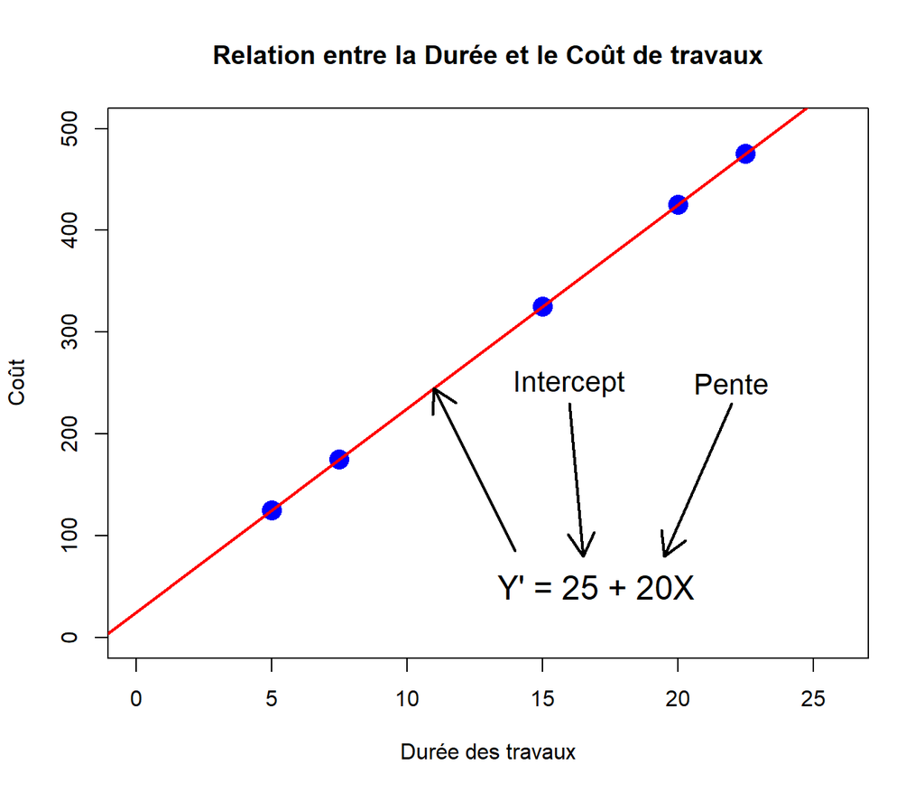

Figure 15.6: Modèle déterministe de la relation entre la durée d’un travail et son coût.

```r
plot(dat,
     main="Relation entre la Durée et le Coût de travaux",
     xlab="Durée des travaux",
     ylab="Coût",col="blue",
     xlim=c(0,26),
     ylim=c(0,500),
     pch=16, cex=2)
abline(lm(cout~duree), col="red", lwd=2)
text(17, 50, "Y' = 25 + 20X", cex=1.5)
arrows(14, 85, 11, 245, length=0.2, lwd=2)
text(16, 250, "Intercept", cex=1.3)
arrows(16, 230, 16.5, 80, length=0.2, lwd=2)
text(22, 250, "Pente", cex=1.3)
arrows(22, 230, 19.5, 80, length=0.2, lwd=2)
```

L’équation traduisant ce modèle est formée de deux paramètres:

- l’intercept : valeur de la variable dépendante pour une variable indépendante nulle. Ici, il s’agirait du coût d’un travail dont la durée est nulle. Dans un cas réel, il pourrait s’agir des frais administratifs (25 Gourdes) pour l’ouverture d’un dossier-client, par exemple. Il s’agit d’une constante. Dans la littérature statistique, on symbolise l’intercept d’un échantillon par $b_0$, et d’une population par $\beta_0$.
- la pente : augmentation dans la valeur de la variable dépendante pour une augmentation d’une unité de la variable indépendante. Ici, la pente indique que pour chaque heure de travail ($\Delta X=1$), 20 gourdes s’ajoutent à la facture. Dans la littérature statistique, on symbolise l’intercept d’un échantillon par $b_1$, et d’une population par $\beta_1$.

La figure Figure 15.7 résume ces deux concepts.

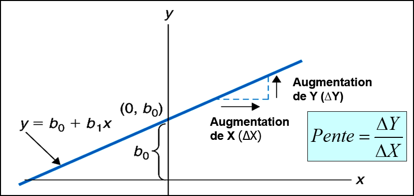

Figure 15.7: Équation générale d’une droite et ses paramètres

#### 15.2.0.2 2. Une portion **probabiliste** ou **stochastique**:

La portion **probabiliste** du modèle réflète la nature aléatoire des résultats obtenus en appliquant le modèle. On tient compte et on quantifie la variation dans les résultats de son application: on obtient la **variance d’erreur**, qui est elle-même un paramètre de ce modèle. Par exemple, considérons un modèle simple liant la performance à un examen (Perf) au nombre d’heures passées à le préparer (Étude):

$$Perf=2(Étude) + 1.5 + e$$

Selon ce modèle, chaque heure d’étude devrait augmenter de 2 unités de performance, **en moyenne**; s’il n’y a aucune étude préparatoire (Étude=0), on s’attend à un score de performance égal à 1.5. Les paramètres de la portion déterministe du modèle sont le coefficient lié à la variable indépendante (Étude) et une constante. Cependant, il y a plusieurs facteurs qui ne sont pas pris en considération dans ce modèle et qui sont susceptibles d’influencer la performance d’une manière ou d’une autre. Ces facteurs sont réunis dans un terme d’erreur ($e$) dont la valeur est aléatoire. On ne connait pas sa valeur pour chacun des cas individuels, mais on peut en calculer la variance. Cette variance est aussi un paramètre du modèle, comme le coefficient et la constante. Elle quantifie la portion aléatoire du modèle. La figure Figure 15.8) illustre cette situation.

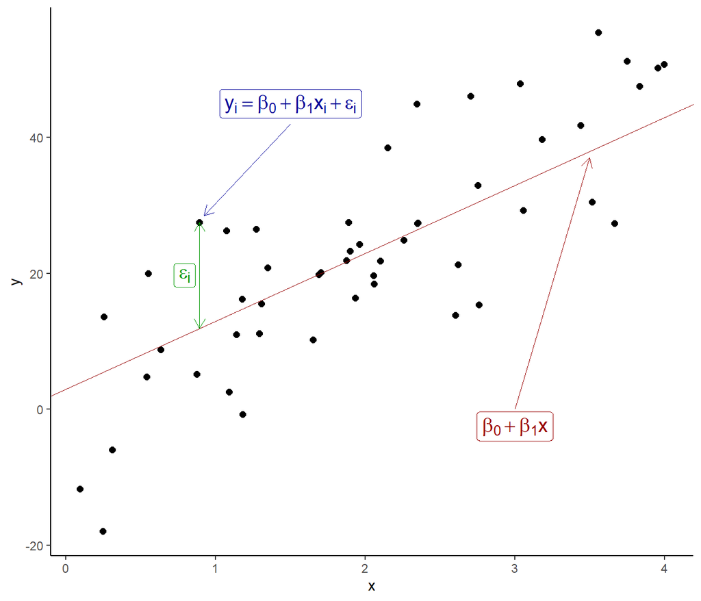

Figure 15.8: Contexte d’un modèle de régression linéaire.

```r
set.seed(1507522)
x <- runif(50, 0, 4)
df <- data.frame(x=x,
                 y=3 + 10*x + rnorm(50, 0, 10))
ggplot(df, aes(x, y)) +
  geom_point(cex=2) +
  geom_abline(slope=10, intercept=3,
              col="#990000", linewidth=0.3) +
  geom_label(x=3, y=-2.5, parse=TRUE, col="#990000",
             cex=5,
             label="beta[0] + beta[1] * x") +
  geom_segment(x=3, y=0, xend=3.5, yend=37,
               arrow=arrow(length = unit(0.02, "npc")),
               linewidth=0.2, col='#990000') +
  geom_label(x=1.5, y=45, parse=TRUE, col="#000099",
             cex=5,
             label="y[i] == beta[0] + beta[1] * x[i] + epsilon[i]") +
  geom_segment(x=1.5, y=42, xend=df$x[31]+0.03, yend=df$y[31]+1,
               arrow=arrow(length = unit(0.02, "npc")),
               linewidth=0.2, col='#000099') +
  geom_segment(x=df$x[31], y=df$y[31],
               xend=df$x[31], yend=3+10*df$x[31],
               col="#009900", linewidth=0.2,
               arrow=arrow(length=unit(0.02,"npc"), ends="both")) +
  geom_label(x=df$x[31]-0.1, cex=5,
             y=(df$y[31]+ 3+10*df$x[31])/2,
             col="#009900", label="epsilon[i]",
             parse=TRUE) +
  theme_classic()
```

Chaque paire de données (X, Y) est représentée par un point dans le plan cartésien. La droite correspond aux valeurs de la variable dépendante prédites (Y’) à partir de la variable indépendante (X). Elle représente la portion **déterministe** du modèle.

La distance séparant un point de la droite est une erreur aléatoire ($\epsilon_i$), variant d’une observation à l’autre. Elle représente la portion **aléatoire** du modèle.

Les deux exemples présentés ci-dessus sont des modèles linéaires, car l’expression mathématique qui les définit est l’équation d’une droite: $y=mX+b$. D’autres modèles impliqueront possiblement des équations plus complexes, curvilinéaires. Dans ce chapitre, nous limitons la discussion aux modèles linéaires.

## 15.3 La régression linéaire simple: variable indépendante dichotomique

Est-ce que la performance moyenne dans un examen de Sciences diffère entre les garçons et les filles au Lycée? C’est le type de question que nous avons abordé dans le contexte des tests d’hypothèse portant sur deux moyennes indépendantes. Regardons la question sous un angle légèrement différent: **‘peut-on expliquer la variation dans la performance dans un examen de Sciences par le sexe des sujets?’**, ou encore **‘peut-on prédire la performance dans un examen de Sciences, connaissant le sexe d’un sujet?’**

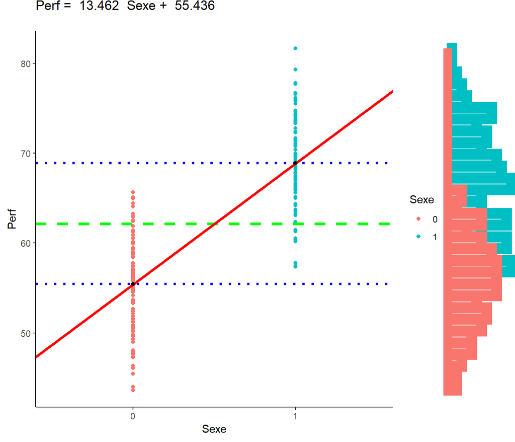

Figure 15.9: Performance en Sciences, en fonction du sexe des sujets.

```r
Perf <- c(rnorm(100, 55, 5), rnorm(100, 68, 5))
Sexe <- as.factor(c(rep(0, 100), rep(1, 100)))
m0 <- mean(Perf[which(Sexe==0)])
m1 <- mean(Perf[which(Sexe==1)])
df <- data.frame(Perf, Sexe)

reg <- lm(Perf ~ Sexe, data=df)
eq <- paste("Perf = ",round(reg$coeff[2],3), " Sexe + ", round(reg$coeff[1], 3))
p <- ggplot(df, aes(Sexe, Perf), show.legend=FALSE) +
  geom_point(aes(colour=Sexe)) +
  theme_classic() +
  aes_string(colour = 'Sexe') +
  geom_hline(yintercept = m0, linetype="dotted", color="blue", linewidth=1.2) +
  geom_hline(yintercept = m1, linetype="dotted", color="blue", linewidth=1.2) +
  geom_hline(yintercept = mean(Perf), linetype="dashed", color="green", linewidth=1.3) +
  geom_abline(intercept = reg$coeff[1]-reg$coeff[2],
              slope = reg$coeff[2],
              color="red",
              linewidth=1.3) +
  geom_point(aes(x=1, y=m0), col="black", linewidth=5) +
  geom_point(aes(x=2, y=m1), col="black", linewidth=5) +
  ggtitle(eq)

ggMarginal(
  p,
  type = 'histogram',
  margins = 'y',
  linewidth = 5,
  groupColour = TRUE,
  groupFill = TRUE)
```

La variable indépendante est le sexe des sujets, et deux valeurs sont possibles: 0 et 1. Cette variable est représentée par l’axe horizontal. La variable dépendante est une variable quantitative: la performance à l’examen de Sciences. Elle occupe l’axe vertical. La corrélation entre ces deux variables, le point bisérial, est égale à:

```r
r <- cor(Perf, as.numeric(Sexe))
cat("Corrélation Point-Bisérial = ", r)
```

```
#> Corrélation Point-Bisérial =  0.7931634
```

Cette corrélation réflète une forte relation entre les deux variables.

Dans un premier temps, ne tenons pas compte du sexe des sujets et examinons l’ensemble des données recueillies. Pour l’ensemble des sujets, garçons et filles ($n=200$), on obtient la distribution affichée dans la marge droite du graphique. La moyenne de cette distribution est indiquée par la ligne verte ($\bar Y = 62.167$). Si vous ne connaissez pas le sexe d’un individu et qu’on vous demande de prédire son score à l’examen de Sciences, la meilleure réponse que vous pourriez donner, celle qui vous amènerait à réduire l’importance de l’erreur inévitable dans une telle situation, serait: **la moyenne de l’ensemble**. C’est en effet la meilleure prédiction que l’on puisse faire, si on ne dispose d’aucune information additionnelle pour guider notre choix.

En séparant les données des garçons de celles des filles, on obtient deux distributions. Les données sont représentées par des points pour chacune des deux valeurs de la variable sexe, et la distribution résultante pour chaque groupe est projetée sur la marge de droite, différenciée par la couleur. La moyenne de chaque groupe est indiquée par les lignes pointillées bleues. On note une différence, la performance moyenne des garçons étant différente de celle des filles.

Maintenant, si on vous informe qu’un individu est un garçon, quelle serait votre prédiction quant à sa performance à l’examen de Sciences? Vous répondriez sûrement que la performance moyenne **des garçons** serait la prédiction la plus précise que vous pourriez faire, tenant compte du fait que la performance moyenne des garçons diffère de celle des filles. Et vous auriez raison. Clairement, il y aura erreur, mais l’erreur sera plus faible en tenant compte du sexe du sujet, que si vous n’en teniez pas compte.

En bref, s’il existe une relation entre deux variables, il devient possible de prédire la valeur de l’une à partir de l’autre. Dans certains cas, si certaines conditions sont respectées, il sera possible d’affirmer que la variable indépendante a une influence sur la variable dépendante, et peut-être même qu’elle en est la ‘cause’! Mais la route est encore longue avant d’en arriver là…

## 15.4 La régression linéaire simple: variable indépendante quantitative

Dans la section précédente, la relation entre une variable dichotomique (sexe des sujets) et une variable quantitative (performance à un examen de Sciences) a été mise à profit pour formuler un modèle explicatif ou prédictif: le sexe des sujets a un impact sur la performance, ou connaissant le sexe des sujets, on peut obtenir une meilleure estimation de la performance d’un individu.

Examinons maintenant la relation entre deux variables quantitatives. Les concepts demeurent les mêmes; il n’y a simplement un plus grand nombre de valeurs possibles pour la variable indépendante.

La figure Figure 15.10) illustre la situation. Deux variables y sont représentées. Considérons la variable occupant l’axe horizontal comme étant la variable indépendante (X), et celle occupant l’axe vertical comme étant la variable dépendante (Y).

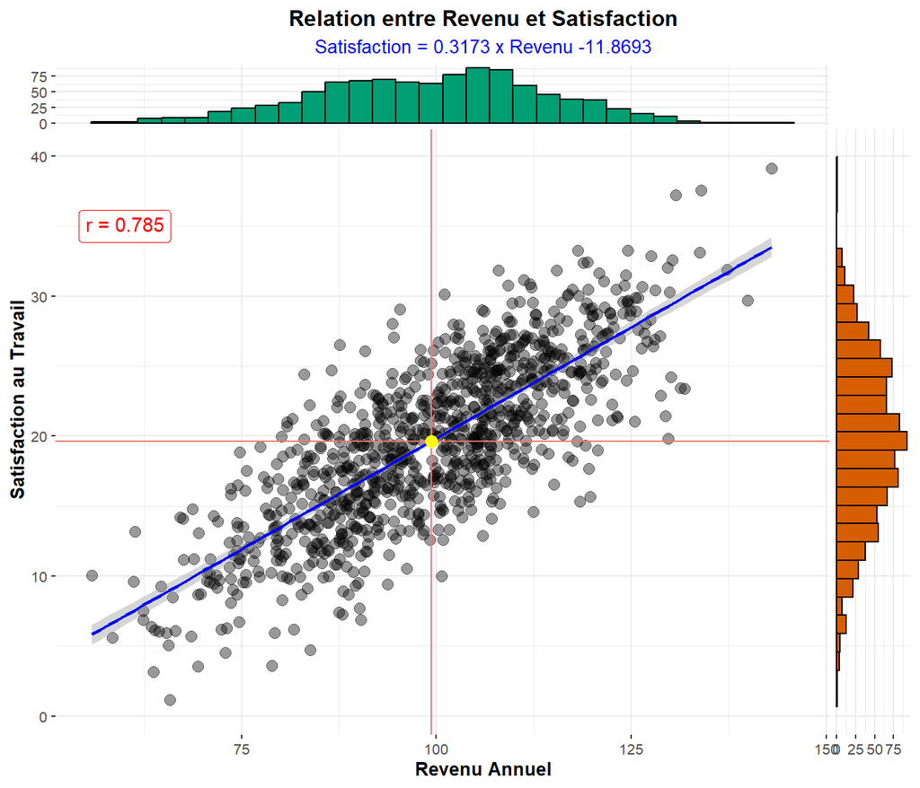

Figure 15.10: Relation entre X et Y, deux variables quantitatives.

```r
set.seed(150752)
r <- 0.8
x <- rnorm(1000)
y <- x * r + rnorm(1000) * sqrt(1-r^2)
x <- x * 15 + 100
y <- y * 6 + 20
r <- cor(x,y)
df <- data.frame(x, y)
reg <- lm(y~x, data=df)
b0 <- reg$coefficients[1]
b1 <- reg$coefficients[2]
eq = paste0("Satisfaction = ", round(reg$coeff[2],4), " x Revenu ", round(reg$coeff[1],4))

ggstatsplot::ggscatterstats(
  data=df,
  x = x,
  y = y,
  xlab = "Revenu Annuel",
  ylab = "Satisfaction au Travail",
  title = "Relation entre Revenu et Satisfaction",
  subtitle = eq,
  bf.message = FALSE,
  results.subtitle = FALSE,
  smooth.line.args = list(linewidth = 0.8, color = "blue", method = "lm", formula = y ~ x)
) +
  geom_hline(aes(yintercept=mean(y),
               linetype="dashed", color = "red")) +
  geom_vline(aes(xintercept=mean(x),
               linetype="dashed", color = "red")) +
  geom_point(aes(x=mean(x), y=mean(y)), colour="yellow", size=3) +
  annotate("richtext",
           label = paste("r = ", round(cor(x, y), 3)),
           x = 60,
           y = 35,
           color = "red") +
  theme(legend.position="none",
        plot.title = element_text(hjust = 0.5),
        plot.subtitle = element_text(hjust = 0.5,
                                     colour = "blue"))
```

La distribution de la variable dépendante est reproduite dans la marge droite, alors que la distribution de la variable indépendante occupe la marge supérieure. Les lignes rouges pointent vers la moyenne de chacune de ces variables ($\bar X=99.321, \bar Y = 19.646$), et on peut noter que le point défini par le couple ($\bar X, \bar Y)$ (point jaune) se trouve exactement au centre de gravité du nuage de points: c’est le **centroide**.

La corrélation entre X et Y est $r_{xy}=0.785$, une relation forte, compte tenu du nombre d’observations.

Pour donner un contexte à ces données, supposons que Y est un indice de satisfaction au travail, et que X est le revenu annuel d’un individu. La question est de savoir: ‘**Peut-on expliquer la satisfaction au travail par le revenu que rapporte ce travail?**’, ou ‘**Est-ce qu’un changement au niveau du revenu se traduirait par un changement du niveau de satisfaction au travail?**’

Dans un premier temps, ne tenons pas compte du revenu annuel et examinons l’ensemble des données recueillies. Pour l’ensemble des sujets, on obtient la distribution affichée dans la marge droite du graphique. La moyenne de cette distribution est indiquée par la ligne horizontale rouge. Si on ne connait pas le revenu annuel d’un individu et qu’on cherche à déterminer son niveau de satisfaction au travail, la meilleure estimation que l’on puisse faire de cette quantité est, comme dans l’exemple précédent, **la moyenne de l’ensemble**. C’est en effet la meilleure prédiction que l’on puisse faire, si on ne dispose d’aucune information additionnelle pour guider notre choix.

Considérons maintenant l’information contenue dans la variable indépendante, le revenu. On note qu’un revenu élevé semble être associé à une grande satisfaction au travail, alors qu’un revenu faible serait associé à une faible satisfaction. Donc si on vous présente un individu dont le revenu est élevé, vous auriez avantage à prendre en compte cette donnée et plutôt que de prédire une valeur égale à la moyenne de la variable dépendante, vous devriez examiner les données disponibles pour l’ensemble des individus ayant le même revenu, et en calculer la moyenne. Cette moyenne, qui serait de fait une **moyenne conditionnelle** ($\mu_{Y|X}$), serait alors la meilleure prédiction que vous pourriez faire, celle qui produirait l’erreur la plus faible. C’est exactement ce que nous avons fait dans l’exemple de la section précédente, sauf qu’ici, la variable est continue plutôt que dichotomique.

La droite traversant le nuage de points (trait bleu) est celle qui représente le mieux les données. L’intercept (la constante) est $b_0=-11.869$ . Cette quantité correspond au niveau de satisfaction au travail pour un individu dont le revenu annuel est nul. La pente de la droite est $b_1=0.317$. Cette quantité correspond au changement dans la valeur de la variable dépendante (**satisfaction**) pour un changement d’une unité dans la variable indépendante (**revenu**).

Conceptuellement, le problème à résoudre est simple: quelles sont les moyennes des observations sur la variable dépendante pour chacune des valeurs possibles de la variable indépendante? La tâche semble gigantesque à première vue, mais heureusement, elle se résume à déterminer l’équation de la droite qui représente le mieux l’ensemble des données. Rappelons que dans l’exemple présenté dans la section précédente, la droite reliait la moyenne des deux groupes (garçons et filles). Le concept est identique ici, sauf qu’on l’étend à un nombre infini de ‘groupes’.

## 15.5 Simulation de données bivariées

Supposons deux variables($X$ et $Y$) observables pour une population infinie. Au niveau de cette population, les paramètres relatifs à ces deux variables sont:

$$\mu_X=20~~~~~\sigma_x=5$$
$$\mu_Y=40~~~~~\sigma_Y=10$$
$$\rho_{XY}=0.6$$

On tire un grand nombre d’échantillons aléatoires de taille $n=50$, de cette population. Pour chaque échantillon, on calcule le coefficient de corrélation $r_{XY}$, et on estime la pente ($b_1$) et l’intercept ($b_0$) d’une droite représentant bien la relation existant entre les deux variables. De cette manière, on obtient une distribution d’échantillonnage des corrélations, des pentes, et des intercepts. La fonction **RegSim()** (Listing 15.1) permet cette opération. Ses arguments sont:

- nrep = nombre d’échantillons à tirer (défaut = 10000)
- n = taille des échantillons (défaut = 50)
- mux et muy = moyennes des variables X et Y respectivement, au niveau de la population (défaut = 20 et 40)
- sx et sy = écarts-types des variables X et Y respectivement, au niveau de la population (défaut = 5 et 10)
- r = corrélation entre X et Y, au niveau de la population (défaut = 0.6)

Cette fonction retourne une structure formée de trois vecteurs contenant respectivement les corrélations (*NomStruc*$rxy), les intercepts (*NomStruc*$b0) et les pentes (*NomStruc*$b1).

Examinons donc les distributions d’échantillonnage de ces trois quantités, portant une attention particulière à la forme de la distribution, sa moyenne et sa dispersion:

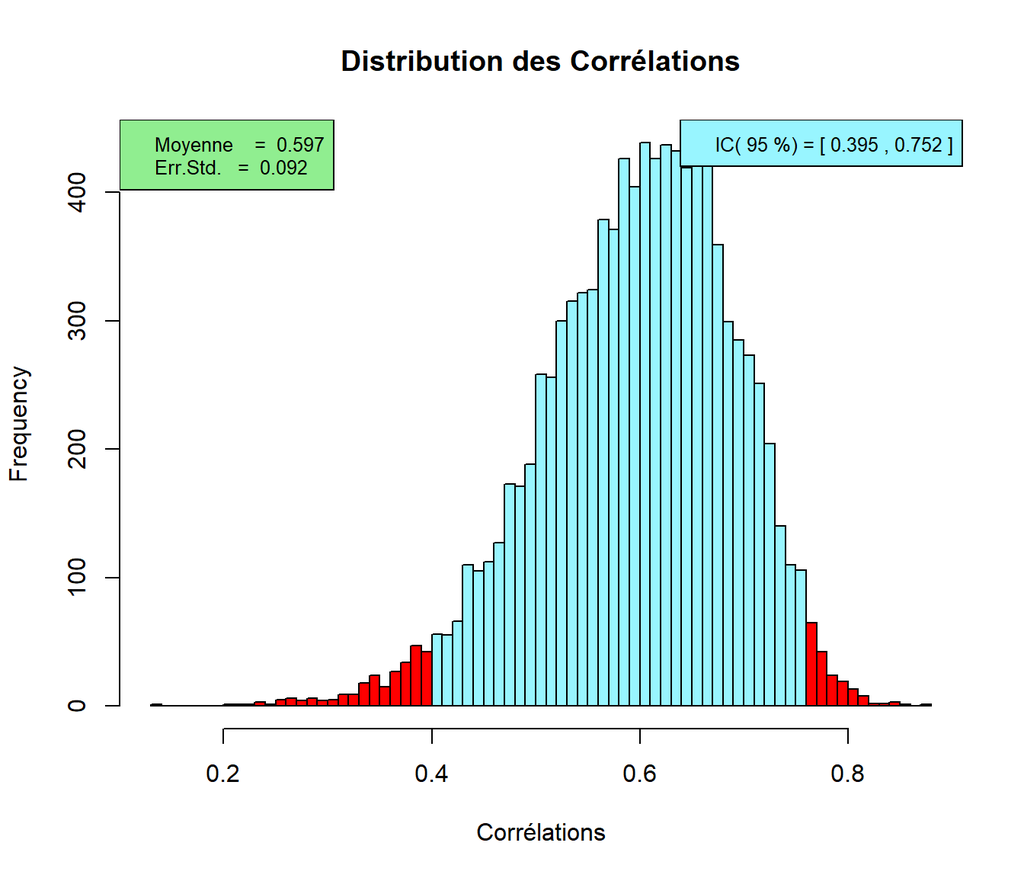

Figure 15.11: Distribution d’échantillonnage des corrélations.

```r
res <- RegSim()
GraphDist(res$rxy, parm="Corrélations")
```

On note que la distribution d’échantillonnage des corrélations (Figure Figure 15.11) est légèrement asymétrique négative, et que sa moyenne est approximativement égale à la corrélation au niveau de la population. L’écart-type de cette distribution est l’erreur-standard des corrélations ($s_{r_{xy}}$). On note également l’intervalle de confiance (95%) pour la corrélation: nous sommes confiants à 95% que $\rho_{XY}$ fait partie des valeurs comprises dans cet intervalle.

La distribution d’échantillonnage des intercepts (Figure Figure 15.12) semble Gaussienne, avec une moyenne s’approchant de l’intercept que l’on obtiendrait si l’ensemble de la population était utilisée, et un erreur-standard qui permettra d’évaluer la marge d’erreur, dans un contexte d’estimation statistique.

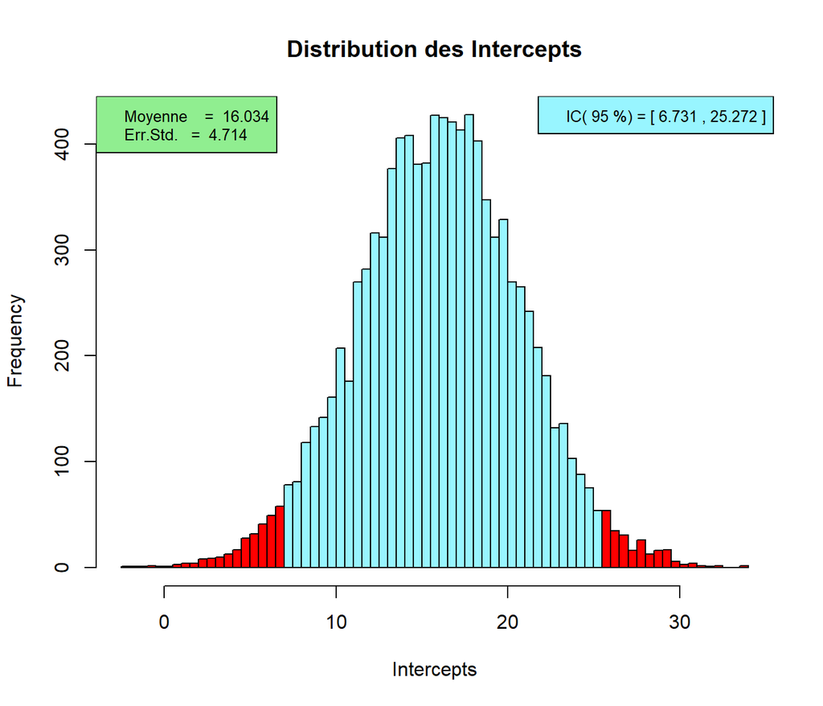

Figure 15.12: Distribution d’échantillonnage des intercepts.

```r
GraphDist(res$b0, parm="Intercepts")
```

Finalement, la distribution d’échantillonnage de la pente ($b_1$) devrait fournir des informations analogues, tel qu’illustré dans la figure Figure 15.13).

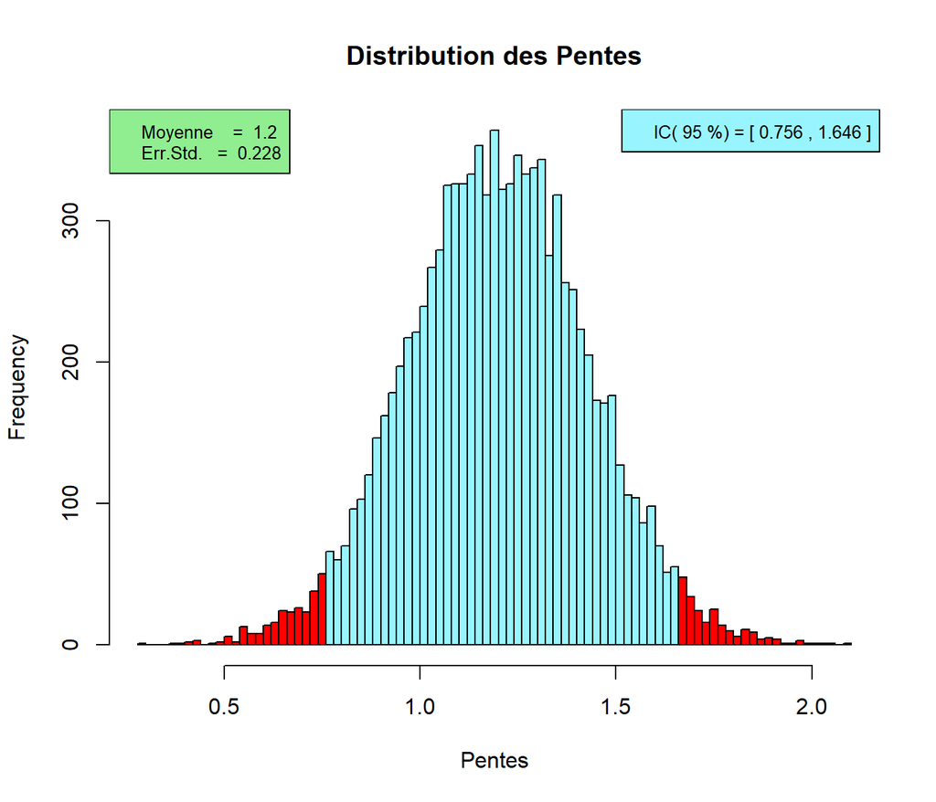

Figure 15.13: Distribution d’échantillonnage des pentes.

```r
GraphDist(res$b1, parm="Pentes")
```

On obtient une distribution en apparence Gaussienne, avec une moyenne que se rapproche de la pente que l’on retrouverait au niveau de la population. Cette distribution, comme dans les autres cas étudiés jusqu’ici, permettra les inférences statistiques concernant la relation entre les variables.

## 15.6 Ajustement visuel d’une droite de régression

La figure Figure 15.14 reproduit une portion de l’interface de l’application [RegAjust](https://daniel-coulombe.shinyapps.io/RegAjust/), qui permet visualiser l’ajustement d’une droite de régression à un ensemble de données bivariées généré aléatoirement. Le degré de relation entre les variables est également choisi de manière aléatoire. En manipulant les curseurs représentant la pente et l’intercept, il est possible de déplacer une droite dans un plan cartésien, de manière à obtenir le meilleur ajustement possible, indiqué par un indice libellé **SCerr**, que l’on cherche à minimiser.

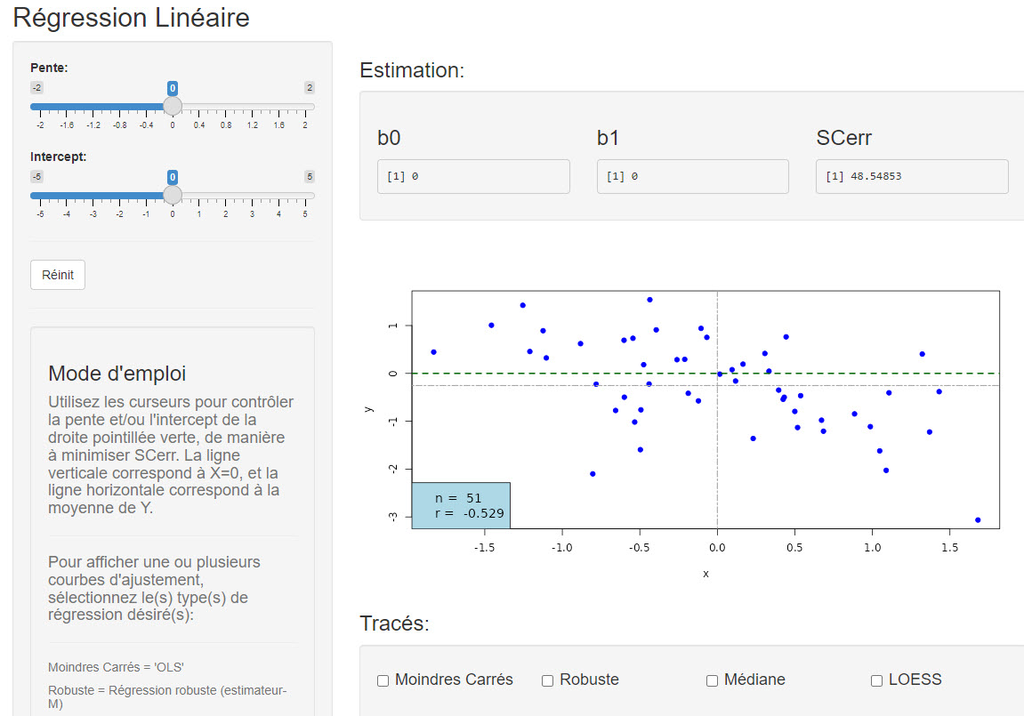

Figure 15.14: Ajustement d’une droite aux données. Cliquez sur l’image pour accéder à l’applicaton

## 15.7 Régression: Approche analytique

En supposant que la relation entre deux variables est linéaire, le problème que nous devons résoudre à ce stade concerne le choix de la droite qui représente, ou s’ajuste le mieux aux données. Comment pouvons-nous déterminer les paramètres de cette droite, soient l’intercept et la pente, de manière à minimiser les erreurs de prédiction? L’exemple suivant, illustré dans la figure Figure 15.15), permettra de mieux cerner le problème.

Considérons les données à la source de la figure Figure 15.15):

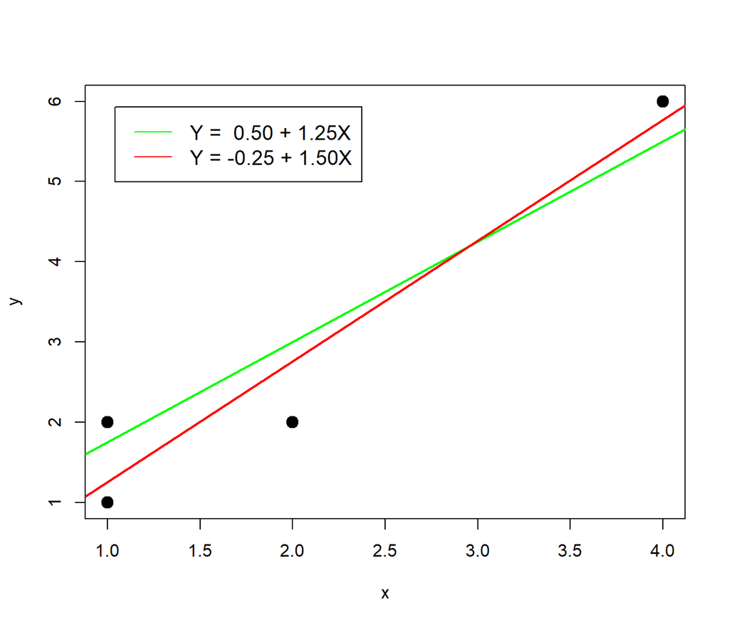

Figure 15.15: Ajustement d’une droite à un ensemble de points.

```r
x <- c(1, 1, 2, 4)
y <- c(1, 2, 2, 6)
plot(x,y, pch=19, cex=1.5)
abline(a=0.5, b=1.25, col="green", lwd=2)
abline(a=-0.25, b=1.505, col="red", lwd=2)
legend("topleft",
       inset=0.05,
       legend=c("Y =  0.50 + 1.25X", "Y = -0.25 + 1.50X"),
       col=c("green", "red"),
       cex=1.2,
       lty=1)
```

Les deux droites semblent s’ajuster assez bien aux données, et on pourrait en ajouter plusieurs autres! Chacune de ces droites est déterminée par un intercept et une pente spécifiques. Mais parmi ces droites, laquelle choisir?

La solution se trouve dans l’examen des erreurs, c’est-à-dire la distance qui sépare un point donnée de la droite considérée. Dans les tableaux Table 15.2), on retrouve:

- les données originales, X et Y
- la valeur prédite de Y que l’on obtient en introduisant une valeur de X dans l’équation définissant la droite
- l’erreur, $e_i = Y_i-\hat Y$
- le carré de l’erreur, $e_i^2$

Table 15.2: Détermination de la qualité de l’ajustement.

| Y=0.5+1.25X x | Y=0.5+1.25X y | Y=0.5+1.25X yp | Y=0.5+1.25X e | Y=0.5+1.25X e2 | Y=-0.25+1.5X x | Y=-0.25+1.5X y | Y=-0.25+1.5X yp | Y=-0.25+1.5X e | Y=-0.25+1.5X e2 |
| --- | --- | --- | --- | --- | --- | --- | --- | --- | --- |
| 1 | 1 | 1.75 | -0.75 | 0.5625 | 1 | 1 | 1.25 | -0.25 | 0.0625 |
| 1 | 2 | 1.75 | 0.25 | 0.0625 | 1 | 2 | 1.25 | 0.75 | 0.5625 |
| 2 | 2 | 3 | -1 | 1 | 2 | 2 | 2.75 | -0.75 | 0.5625 |
| 4 | 6 | 5.5 | 0.5 | 0.25 | 4 | 6 | 5.75 | 0.25 | 0.0625 |
|  |  | TOTAL | -1.00 | 1.875 |  |  | TOTAL | 0.00 | 1.25 |

On note que la somme des erreurs ($\sum e_i$) n’est pas nulle dans le cas de l’équation de gauche (**Y = 0.5+1.25X** ), mais elle l’est dans le cas de l’équation de droite (**Y = -0.25+1.5X** ). Rappelons que pour un ensemble de scores donné, la somme des écarts par rapport à la moyenne [$\sum (X- \bar X)$] est toujours égale à 0. Toute autre valeur remplaçant la moyenne produira une somme différente de 0. Intuitivement, on peut donc concevoir la droite comme une structure apparentée à la *moyenne*.

On note également que la somme des carrés des erreurs ($\sum e^2$) est plus petite pour l’équation de droite que pour celle de gauche. Plus cette quantité est faible, plus la qualité de l’ajustement de la droite par rapport aux données est grande. On peut donc affirmer que la droite représentant le mieux un ensemble de données est celle qui **minimise** la somme des carrés des erreurs. Formellement, cet énoncé se traduit par l’équation Équation 15.11).

$$f_e=\sum(Y-Y')^2= \sum(Y-[b_0+b_1X])^2\Longrightarrow minimum \tag{15.11}$$

En d’autres termes, les paramètres de la droite ($b_0$ et $b_1$) sont ceux qui minimisent la somme des carrés des erreurs: c’est le **critère des moindres carrés**. Graphiquement, on peut représenter ce concept par la figure Figure 15.16).

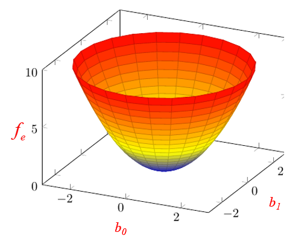

Figure 15.16: Fonction d’erreur et critère des moindres carrés

L’axe vertical correspond à $f_e=\sum(Y-Y')^2$, alors que les deux autres axes représente les valeurs possibles de $b_0$ et de $b_1$, respectivement. Il n’existe qu’une seule paire ($b_0, b_1$) produisant le minimum de cette fonction. Ce sont donc les paramètres recherchés.

La solution de ce problème est donc simple: il suffit de calculer les dérivées partielles de la fonction d’erreur (une simple fonction du second degré) par rapport à $b_0$ et à $b_1$, les rendre égales à 0, pour ensuite solutionner le système d’équations résultant de cette opération. Mais il y a plus simple encore! Examinons les définitions formelles de l’**équation de régression**, l’équation de la droite susceptible de bien s’ajuster aux données et de permettre les prédictions les plus précises possible.

#### 15.7.0.1 La droite de régression: Simulation

Pour illustrer la recherche du point minimum de la fonction d’erreur, considérons deux variables, X et Y, mesurées sur un échantillon de $n=50$ sujets. La corrélation entre ces deux variables au niveau de la population est $\rho_{XY}=0.85$. Suivant l’équation Équation 15.12), il suffit de générer deux variables gaussiennes ($X_{rnd}$ et $Z_{rnd}$), toutes deux centrées et réduites ($\mu=0$ et $\sigma=1$), pour obtenir deux variables (X et y) corrélées. La corrélation entre ces deux variables devrait avoisiner le $\rho$ spécifié. La première opération ($\rho \times X$) prend en charge la portion déterministe du modèle, alors que la seconde ($\sqrt{1-\rho^2}\times Z$) introduit la portion aléatoire.

$$X=X_{rnd}$$
$$Z=Z_{rnd}$$
$$y=[\rho \times X]+\left [\sqrt{1-\rho^2}\times Z \right ] \tag{15.12}$$

Par la suite, on pourra modifier l’échelle de mesure de la manière habituelle (équation Équation 15.13)):

$$X^T=X \times \sigma + \mu \tag{15.13}$$

Mettant à l’épreuve ces différentes fonctions, on repositionne X sur une échelle dont $\mu_X=50$ et $\sigma_X=8$, et Y sur une échelle dont $\mu_Y=100$ et $\sigma_Y=12$. Les données ainsi générées sont représentées dans la figure Figure 15.17).

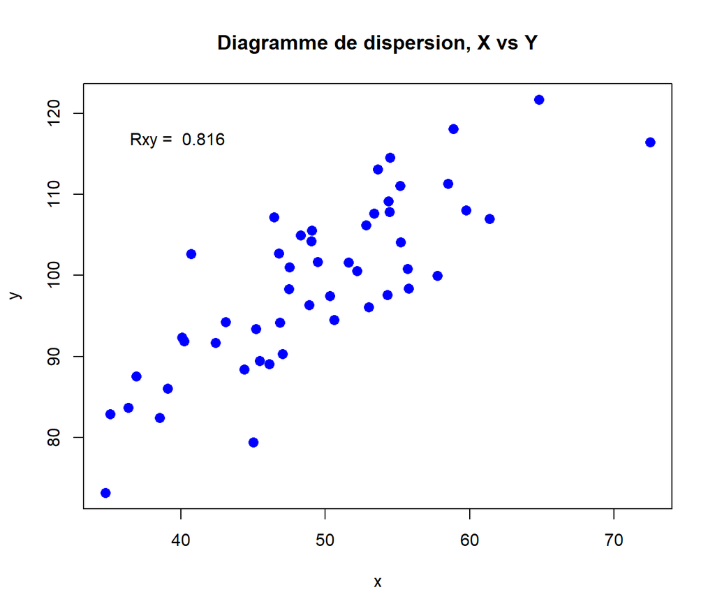

Figure 15.17: Relation entre deux variables, X et Y.

```r
r <- 0.85
x  <-  rnorm(50)
y  <-  r * x + sqrt(1-r^2)*rnorm(50)
r <- cor(x, y)
x <- 8 * x + 50
y <- 12 * y + 100
plot(x,y,
     main="Diagramme de dispersion, X vs Y",
     pch=16, col="blue", cex=1.3)
text(min(x)+5,
     max(y)-5,
     paste("Rxy = ", round(cor(x,y),3)))
```

De cette figure on note une relation positive avoisinant $r_{XY}= 0.816$, une forte relation qui pourrait justifier une approche prédictive. Dans ce cas, l’objectif est de déterminer l’équation d’une droite traversant ce nuage de points, $Y'=b_0+b_1X$ en choisissant $b_0$ et $b_1$ de telle sorte que le critère des moindres carrés soit respecté. En d’autres termes, il faut trouver les valeurs de $b_0$ et de $b_1$ qui produisent la plus petite valeur de la fonction d’erreur, $f_e=\sum(Y-Y')^2$. Une stratégie qui pourrait nous aider dans ce contexte consiste à former une grille à partir d’un ensemble de valeurs possibles de $b_0$ et de $b_1$. Par exemple, considérons $b_0 \in \{20,...,40\}$ par étapes de 0.05, et $b_1 \in \{0.5,...,2\}$ par étapes de 0.01:

- Pour chaque paire de valeurs de ces paramètres, on calcule les valeurs prédites ($Y'$) de la variable dépendante (Y)…
- Ce qui nous permet d’obtenir les erreurs ($Y-Y'$)…
- … que l’on élève au carré et que l’on somme pour obtenir la somme des carrés des erreurs $SC_{erreur}=\sum(Y-Y')^2$
- On recherche ensuite la paire produisant la plus petite $SC_{erreur}$.

```r
# Initialisation des variables et création de la grille b0 x b1
b0 <- seq(20, 40, 0.05)
b1 <- seq(0.5, 2, 0.01)
ix <- 0
res <- rep(NA, 3)
# Calcul de SCe pour chaque paire (b0, b1)
for(i in 1:length(b0)){
  for(j in 1:length(b1)){
    yp <- b0[i]+b1[j] * x
    se2 <-  sum((y-yp)^2)
    res <- rbind(res, c(b0[i],b1[j],se2))
  }
}
# Préparation des résultats
colnames(res) <- c("b0", "b1", "SCe")
shr <- data.frame(res[(which.min(res[-1, 3])-10):(which.min(res[-1, 3])+10), ])
rownames(shr) <- NULL
minshr <- which.min(shr[, 3])
RowMin <- shr[minshr, ]
```

Le tableau Table 15.3) reproduit la portion de la grille $b_0\times b_1$ bordant le minimum de la fonction d’erreur (indiqué en rouge). Ce minimum survient lorsque $b_0=39.85$ et $b_1=1.2$. À ce point, la somme des carrés des erreurs est $SC_{erreur}=1834.4201$. Parmi le nombre infini de droites que l’on pourrait tracer dans le nuage de points, celle qui respecte le critère des moindres carrés est:

$$Y'= 39.85+ 1.2X$$

```r
# Affichage du tableau
shr %>%
  kbl(caption="Minimisation de SCe", digits=3) %>%
  kable_styling(bootstrap_options = c("striped", "hover", "condensed"), full_width=FALSE) %>%
  column_spec(3, bold=TRUE, border_right=TRUE) %>%
  column_spec(1, bold=FALSE, border_left=TRUE) %>%
  row_spec(minshr, bold=TRUE, color="red")
```

Table 15.3: Recherche de la valeur minimum de SCe, obtenue pour une paire spécifique de $b_0$ et de $b_1$.

Minimisation de SCe

| b0 | b1 | SCe |
| --- | --- | --- |
| 39.85 | 1.09 | 3282.456 |
| 39.85 | 1.10 | 3025.696 |
| 39.85 | 1.11 | 2793.960 |
| 39.85 | 1.12 | 2587.248 |
| 39.85 | 1.13 | 2405.560 |
| 39.85 | 1.14 | 2248.896 |
| 39.85 | 1.15 | 2117.257 |
| 39.85 | 1.16 | 2010.641 |
| 39.85 | 1.17 | 1929.050 |
| 39.85 | 1.18 | 1872.482 |
| 39.85 | 1.19 | 1840.939 |
| 39.85 | 1.20 | 1834.420 |
| 39.85 | 1.21 | 1852.925 |
| 39.85 | 1.22 | 1896.454 |
| 39.85 | 1.23 | 1965.008 |
| 39.85 | 1.24 | 2058.585 |
| 39.85 | 1.25 | 2177.187 |
| 39.85 | 1.26 | 2320.812 |
| 39.85 | 1.27 | 2489.462 |
| 39.85 | 1.28 | 2683.136 |
| 39.85 | 1.29 | 2901.834 |

La figure Figure 15.18 en fournit une illustration.

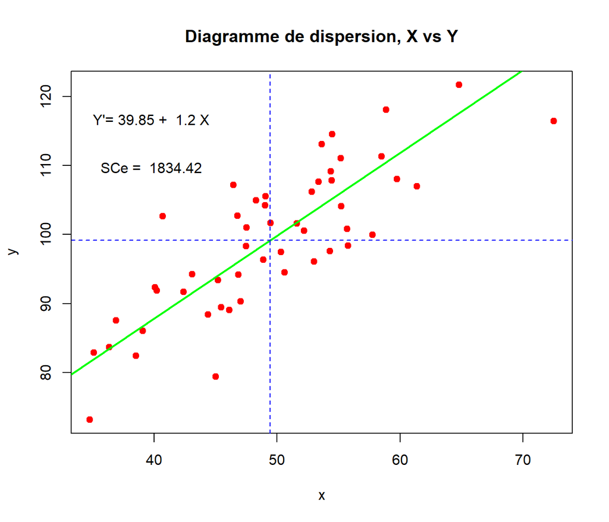

Figure 15.18: Ajustement de la droite aux données, utilisant les paramètres fournissant la plus faible somme des carrés des erreurs (SCe).

```r
plot(x, y,
     main="Diagramme de dispersion, X vs Y", pch=19, col="red")
abline(as.numeric(RowMin[1]),
       as.numeric(RowMin[2]),
       col="green", lwd=2)
abline(h=mean(y),
       lty=2, col="blue")
abline(v=mean(x),
       lty=2, col="blue")
text(min(x)+5, max(y)-5,
     paste("Y'=",
           round(RowMin[1],2),"+ ",
           round(RowMin[2],3), "X"))
text(min(x)+5, max(y)-12,
     paste("SCe = ", round(RowMin[3],3)))
```

Le processus de recherche des paramètres de la droite a nécessité, dans le cas présent, 60,000 itérations qui ont résulté en autant de valeurs de $SC_{erreur}$. On comprendra qu’il devrait exister une approche moins lourde sur le plan computationnel pour obtenir le résultat recherché! La simulation a été utilisée afin d’illustrer ce que représente la droite de régression. Dans le paragraphe suivant, nous abordons la détermination de cette droite de manière analytique.

### 15.7.1 La droite de régression: Scores Z

Il devrait y avoir une étroite relation entre le coefficient de corrélation et le coefficient de régression. En effet, lorsque $r_{XY} = \pm1$, tous les points représentant les données s’alignent le long de la droite, et l’équation de régression devient: $Y'=b_0+b_1 X$, sans qu’il y ait d’erreur. Ce lien est mis en évidence formellement dans l’expression la plus simple de l’équation de régression, impliquant les scores standardisés sur les deux variables (équation Équation 15.14).

$$Z_{y}'=r_{xy}Z_x \tag{15.14}$$

Pour les données générées au début de la section Section 15.7.0.1, on obtient la figure Figure 15.19:

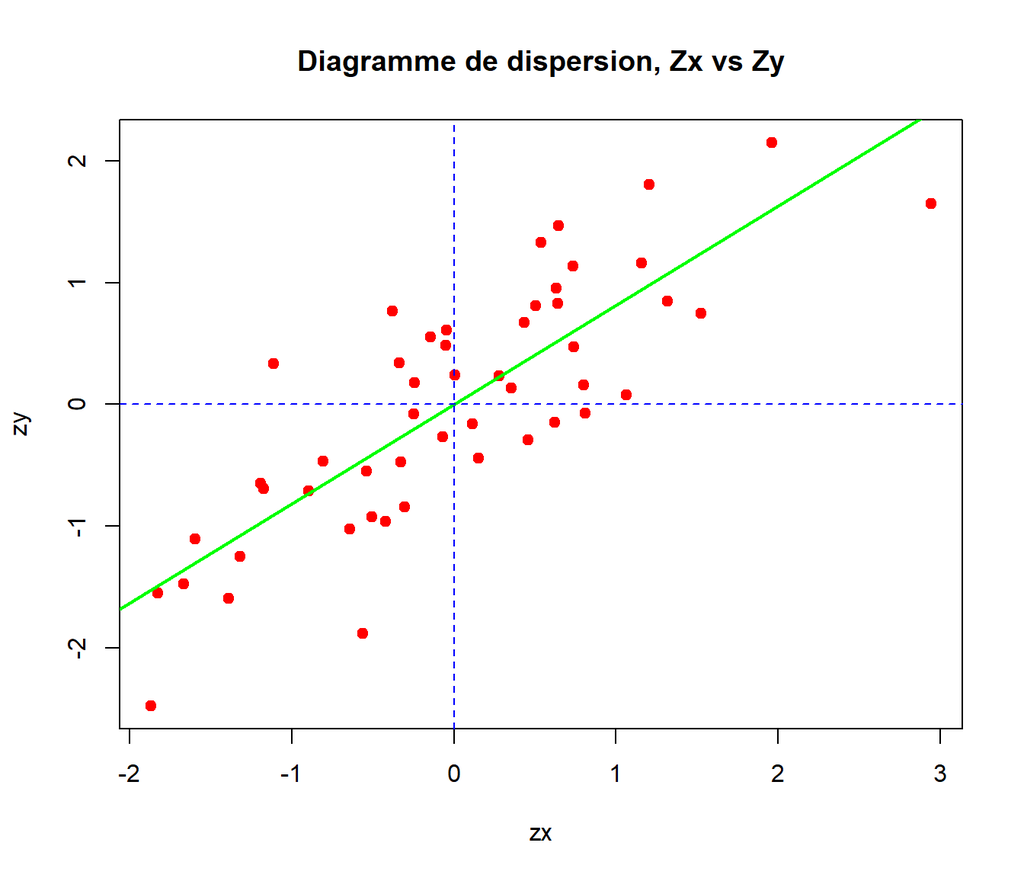

Figure 15.19: Diagramme de dispersion, Zx vs Zy.

```r
zx <- (x - mean(x)) / sd(x)
zy <- (y - mean(y)) / sd(y)
rxy <- cor(x,y)
plot(zx, zy,
     main="Diagramme de dispersion, Zx vs Zy",
     pch=19, col="red")
abline(0, rxy, col="green", lwd=2)
abline(h=0, lty=2, col="blue")
abline(v=0, lty=2, col="blue")
text(min(x)+0.5, max(y)-0.75,
     paste("Zy'= ", round(rxy,3), "Zx"))
```

### 15.7.2 La droite de régression: Statistiques descriptives

Par simple manipulation algébrique, on obtient une expression (équation Équation 15.15) de la droite de régression à partir de la corrélation $r_{XY}$, et des moyennes et écarts-types des deux variables:

$$Y'=\left[r_{xy}\left(\frac{s_y}{s_x} \right) \right ]X -\left[r_{xy}\left(\frac{s_y}{s_x} \right) \right ]\bar X+\bar Y \tag{15.15}$$

De cette équation, on constate la relation existant entre le coefficient de corrélation et le coefficient de régression non-standardisé: la pente est complètement déterminée par la corrélation et la variation observée dans les deux variables (Équation 15.16):

$$b_1= \left[r_{xy}\left(\frac{s_y}{s_x} \right) \right ] \tag{15.16}$$

Pour sa part, l’intercept est déterminé par la pente et les deux moyennes (Équation 15.17):

$$b_0=-b_1 \bar X + \bar Y \tag{15.17}$$

Pour les données générées au début de la section Section 15.7.0.1, on obtient les indices descriptifs reproduits dans le tableau Table 15.4).

Table 15.4: Statistiques Descriptives pour X et Y.

|  | X | Y |
| --- | --- | --- |
| Moyenne | 49.418 | 99.162 |
| Écart-Type | 7.844 | 10.491 |
| Corrélation |  | 0.816 |

La droite de régression se définit donc par l’équation Équation 15.18

$$\hat Y=\left[0.816 \left(\frac{10.491}{7.844} \right) \right ]X -\left[0.816 \left(\frac{10.491}{7.844} \right) \right ]49.418 + 99.162 \tag{15.18}$$

d’où :

$$\hat Y= 1.092 X + 45.205$$

### 15.7.3 L’erreur-standard d’estimation

Ce résultat indique qu’un individu obtenant $x=1.5$ sur la variable indépendante obtiendra **en moyenne** un score $y=46.842$ sur la variable dépendante. Formellement,

$$\mu_{y|x=1.5}=46.842$$
.

Plus la relation entre les deux variables sera forte, plus cette prédiction sera précise. Dans le cas d’une relation parfaite, la prédiction sera exacte.

Il semble évident que l’on doive introduire la notion de **dispersion** des points autour de la droite de régression. On possède déjà une bonne indication de la **tendance centrale** (la droite de régression), il nous reste à quantifier le degré de dispersion autour de cette droite. Dans un contexte univarié, la dispersion des données autour de la moyenne est quantifiée par la variance et par l’écart-type, définis par les relations:

$$s_x^2=\sum\limits_{i=1}^{n}{\frac{(X-\bar X)^2}{n-1}}$$
$$s_x=\sqrt{\sum\limits_{i=1}^{n}{\frac{(X-\bar X)^2}{n-1}}} \tag{15.19}$$

Dans le contexte bivarié, la droite de régression, $Y'$ ou $\hat Y$ tient lieu de *moyenne conditionnelle* (la moyenne dépend de la valeur de X), et les erreurs ($e_i$) sont les écarts par rapport à cette quantité ($Y-Y'$). Par simple subsitution, on peut écrire:

$$s_{y.x}^2=\sum\limits_{i=1}^{n}{\frac{(Y-Y')^2}{n-2}}$$
$$s_{y.x}=\sqrt{\sum\limits_{i=1}^{n}{\frac{(Y-Y')^2}{n-2}}} \tag{15.20}$$

On obtient une mesure de la **variance des erreurs**, et l’**erreur-standard d’estimation**, qui n’est rien de plus ou de moins qu’une forme d’écart-type. Notons ici que le dénominateur tient compte du fait que deux variables sont impliquées, d’où ($n-2$). Mais la parenté des deux mesures (écart-type et erreur-standard d’estimation) demeure évidente.

L’erreur-standard d’estimation définie par la précédente équation a l’avantage de rendre manifeste sa fonction: quantifier la dispersion des données autour de la droite de régression. Cependant, une formulation alternative (et parfaitement équivalente) permet de faire ressortir quelques propriétés particulières:

$$s_{y.x}= \sqrt{\frac{\left[(n-1)s_y^2 \right](1-r_{xy}^2)}{n-2}}=\sqrt{\frac{\left[\sum\limits_{i=1}^{n}{(Y-\bar Y)^2} \right](1-r_{xy}^2)}{n-2}} \tag{15.21}$$

De cette définition, on peut dériver les limites de l’erreur standard. En effet, la valeur de cet indice est largement déterminé par la corrélation existant entre les deux variables. Si $r_{xy}=0$, $s_{yx}=s_y$; et si $r_{xy}=1$, $s_{yx}=0$. Ainsi, l’erreur-standard d’estimation prendra une valeur comprise entre 0, lorsque la corrélation est parfaite (tous les points s’alignant sur la droite), et l’écart-type de la variable dépendante, $s_y$, lorsque la corrélation est nulle (auquel cas la variable indépendante ne contient aucune information nous permettant de prédire autre chose que la moyenne de la variable dépendante).

Pour les données générées à la section Section 15.7.0.1, $n=50$, $s_y^2=110.067$, et $r_{xy}=0.816$, de sorte que:

$$s_{y.x}= \sqrt{\frac{\left[(50-1)110.067 \right](1-0.816^2)}{50-2}}=6.122$$
L’erreur-standard d’estimation, $s_{y.x}=6.122$ est nettement inférieur à l’écart-type de la variable dépendante, $s_y=10.491$, reflétant l’importance de la relation entre les deux variables impliquées dans le modèle.

### 15.7.4 Distribution conditionnelle

À ce stade, nous disposons d’une droite dont les paramètres sont connus, agissant en tant que *tendance centrale*: elle rassemble les **moyennes conditionnelles**, ($\mu_{y|x}$), fonction de la variable indépendante. Nous disposons également d’une mesure de dispersion des points autour de cette droite: **l’erreur-standard d’estimation**, $\sigma_{y.x}$. Pour chaque valeur de la variable indépendante, on peut définir une distribution **conditionnelle**, c’est-à-dire la distribution de Y pour X égal à une valeur donnée. On peut supposer que cette distribution est gaussienne dont les paramètres sont $\mu_{Y|X}$ et $\sigma_{yx}$. La figure Figure 15.20) illustre ce concept.

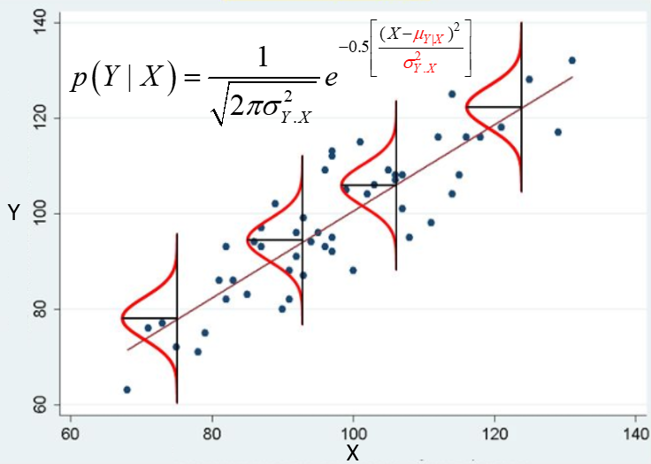

Figure 15.20: Distribution Conditionnelle de Y|X

Pour une distribution conditionnelle donnée (ie pour une valeur donnée de X), tous les calculs de probabilités dérivées de la distribution normale sont permis, et aucune notion additionnelle n’est nécessaire pour mener une telle activité à terme. Certaines conditions doivent être respectées pour en assurer la validité, par contre:

- La droite est un modèle approprié pour représenter l’ensemble des données
- La dispersion des valeurs résiduelles est constante sur toute l’étendue de la variable indépendante (X)
- Les erreurs sont indépendantes les unes des autres
- Pour chaque valeur de la variable indépendante, la distribution conditionnelle de la variable dépendante (Y) est Gaussienne, avec une moyenne $\mu_{Y|X}$ et un écart-type $\sigma_{y.x}$

#### 15.7.4.1 Exemple numérique

Pour illustrer la nature d’une distribution conditionnelle, considérons un exemple simple. On s’intéresse au prix d’une automobile en fonction de son âge. On dispose des données présentées dans le tableau Table 15.5 où sont également affichées les valeurs prédites et résiduelles. La variable **prix** est en unités de $100.

```r
prix <- c(85, 103, 70, 82, 89, 98, 66, 95, 169, 70, 48)
age <- c(5, 4, 6, 5, 5, 5, 6, 6, 2, 7, 7)
model <- lm(prix~age)
res <- moderndive::get_regression_points(model)
colnames(res) <- c("ID", "Prix", "Âge", "Prédit", "Erreur")
res %>%
  kable(
    digits = 3,
    caption = "Données originales, valeurs prédites et résiduelles",
    booktabs = TRUE,
    linesep = ""
  ) %>%
  kable_styling(bootstrap_options = c("striped", "hover", "condensed"),
                full_width=FALSE)
```

Table 15.5: Valeur d’un véhicule en fonction de son âge.

Données originales, valeurs prédites et résiduelles

| ID | Prix | Âge | Prédit | Erreur |
| --- | --- | --- | --- | --- |
| 1 | 85 | 5 | 94.162 | -9.162 |
| 2 | 103 | 4 | 114.423 | -11.423 |
| 3 | 70 | 6 | 73.901 | -3.901 |
| 4 | 82 | 5 | 94.162 | -12.162 |
| 5 | 89 | 5 | 94.162 | -5.162 |
| 6 | 98 | 5 | 94.162 | 3.838 |
| 7 | 66 | 6 | 73.901 | -7.901 |
| 8 | 95 | 6 | 73.901 | 21.099 |
| 9 | 169 | 2 | 154.946 | 14.054 |
| 10 | 70 | 7 | 53.640 | 16.360 |
| 11 | 48 | 7 | 53.640 | -5.640 |

Le tableau Table 15.6 présente les paramètres du modèle et les tests d’hypothèse les concernant.

```r
moderndive::get_regression_table(model) %>%
  kable(
    digits = 3,
    caption = "Régression Linéaire Simple",
    booktabs = TRUE,
    linesep = ""
  ) %>%
  kable_styling(bootstrap_options = c("striped", "hover", "condensed"),
                full_width=FALSE)
```

Table 15.6: Résultats de l’analyse de régression.

Régression Linéaire Simple

| term | estimate | std_error | statistic | p_value | lower_ci | upper_ci |
| --- | --- | --- | --- | --- | --- | --- |
| intercept | 195.468 | 15.24 | 12.826 | 0 | 160.992 | 229.945 |
| age | -20.261 | 2.80 | -7.237 | 0 | -26.594 | -13.928 |

De ce tableau, on apprend que le prix moyen d’un véhicule neuf (âge = 0) est de $19,546.80, une valeur qui est évidemment significativement différente de 0: la droite de régression ne passe pas par l’origine. De manière plus intéressante, on apprend aussi que pour chaque année s’ajoutant à l’âge d’un véhicule, son prix diminue en moyenne de $2,026.10, une réduction significativement différente de 0.

L’équation de régression s’énonce donc de la manière suivante, les erreurs-standards des coefficients étant affichés entre parenthèses, sous le coefficient correspondant:

```r
equatiomatic::extract_eq(model,
                         use_coefs = TRUE,
                         se_subscripts = TRUE)
```

$$\operatorname{\widehat{prix}} = \underset{(15.24)}{195.47} - \underset{(2.8)}{20.26(\operatorname{age})}$$

Le tableau Table 15.7 présente différents indices relatifs à la qualité de l’ajustement. Ces indices seront discutés ultérieurement, mais néanmoins on peut y lire que :

- l’âge d’un véhicule permet d’expliquer $r^2=85.3\%$ de la variabilité de son prix.
- l’erreur-standard d’estimation est égal à $s_{y.x}= 12.577$

```r
get_regression_summaries(model) %>%
  kable(
    digits = 3,
    caption = "Indices de la qualité de l'ajustement",
    booktabs = TRUE,
    linesep = ""
  ) %>%
  kable_styling(bootstrap_options = c("striped", "hover", "condensed"),
                full_width=FALSE)
```

Table 15.7: Indices de la qualité de la régression.

Indices de la qualité de l'ajustement

| r_squared | adj_r_squared | mse | rmse | sigma | statistic | p_value | df | nobs |
| --- | --- | --- | --- | --- | --- | --- | --- | --- |
| 0.853 | 0.837 | 129.412 | 11.376 | 12.577 | 52.38 | 0 | 1 | 11 |

Finalement, le diagramme de dispersion affiché à la figure Figure 15.21 illustre le résultat de cette analyse:

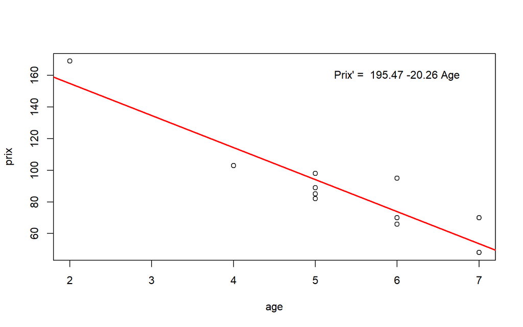

Figure 15.21: Diagramme de dispersion: Prix d’un véhicule enfonction de son âge.

```r
b0 <- summary(model)$coefficients[1]
b1 <- summary(model)$coefficients[2]
plot(age, prix)
abline(model,
       col = "red",
       lwd = 2)
text(6, 160, paste("Prix' = ", round(b0, 2),  round(b1,2), "Age"))
```

À ce stade, il devient possible de répondre à des questions concernant la probabilité de certains événements particuliers. Par exemple:

> **Quelle est la probabilité qu’une automobile âgée de 4 ans soit associée à un prix de 130 unités monétaires?**

Dans le tableau Table 15.5, on retrouve les données observées pour $n=11$ automobiles. De ces données, on trouve l’équation de régression Équation 15.22:

$$\widehat{Prix}=195.468 - 20.261 Age \tag{15.22}$$

Ainsi, tel que mentionné plus haut, pour chaque année d’usage, le prix de l’automobile diminue **en moyenne** de 20.26 unités monétaires ($2026), et une automobile neuve (âge = 0) coûterait **en moyenne** 195.47 unités ($19,547). Pour chaque véhicule, le tableau reproduit les prix prédits (**Prédit**) et la valeur résiduelle **Y-Y’** (**Erreur**). L’erreur-standard d’estimation (**sigma**) est affichée dans le tableau Table 15.7 (**Qualité de l’ajustement**): $s_{yx}=12.577$

Ces résultats nous permettent d’obtenir le prix moyen d’une automobile âgée de 4 ans:

$$\mu_{(Prix|Age=4)}=195.47-20.26(4)=114.43$$

et la distribution conditionnelle correspondante est reproduite dans la figure Figure 15.22).

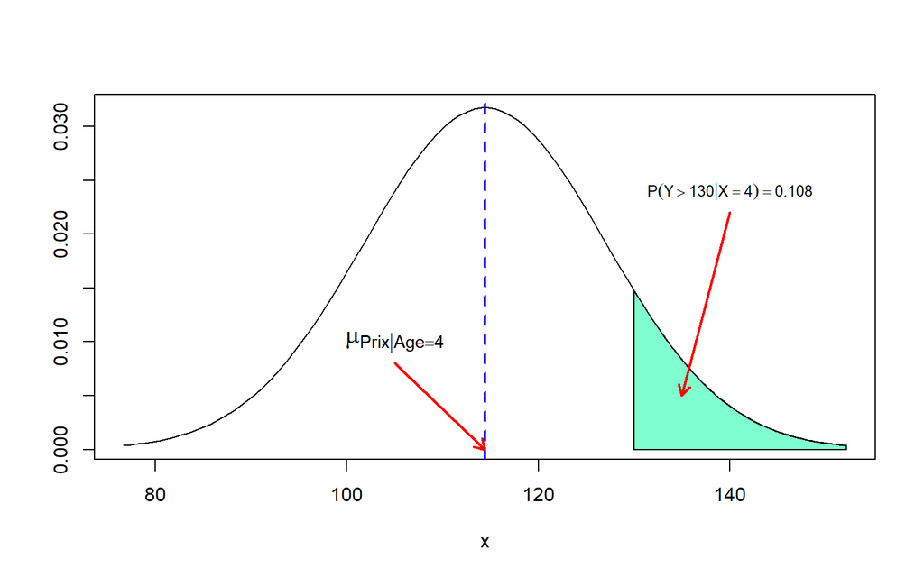

Figure 15.22: Distribution conditionnelle du prix d’un véhicule âgé de 4 ans. Le prix prédit est de 114.43 unités monétaires.

```r
normal_area(114.43, 12.577, lb=130, acolor="#7FFFD0")
abline(v=114.43, lty=2, lwd=2, col="blue")
text(105, 0.01, TeX(r'($\mu_{Prix|Age=4}$)'), cex=1.3)
arrows(105, 0.008, 114.43, 0, length=0.1, col="red", lwd=2)
text(140, 0.024, TeX(r'($P(Y>130|X=4)=0.108$)'), cex=0.8)
arrows(140, 0.022, 135, 0.005, length=0.1, col="red", lwd=2)
```

La probabilité recherchée correspond à l’aire à droite de X (Prix) = 130. La valeur standardisée de cette quantité est:

$$z_{y}=\frac{y-\mu_{y|x}}{\sigma_{y.x}} \implies z_{130}=\frac{130-114.43}{12.577}= 1.238$$
d’où

$$p(z \ge 1.238)= 0.108$$

Utilisant la fonction R **pnorm()**, on obtient:

```r
z <- (130 - 114.43) / 12.577    # Calcul de Z pour X = 130
p <- pnorm(z, lower.tail=FALSE) # Calcul de P(Z > 130)
cat("P(Prix>130|Age=4) = ", p)
```

```
#> P(Prix>130|Age=4) =  0.1078628
```

### 15.7.5 Composantes de la variabilité de la variable dépendante (Y)

La variabilité de la variable dépendante est quantifiée par la variance. Expliquer un phénomène (variable dépendante) revient à déterminer les sources de cette variabilité, à trouver les facteurs qui en sont responsables. Reprenant l’exemple précédent concernant le prix des automobiles, on a trouvé que ce prix dépendait de l’âge du véhicule; connaissant l’âge de ce dernier, on peut établir un prix moyen. Donc l’âge d’un véhicule permet d’expliquer au moins une partie des variations de son prix. D’autres facteurs permettront peut-être d’en expliquer une autre portion (finition intérieure, système de son, nombre de portes, nombre de cylindres, etc).

La figure Figure 15.23) illustre la **décomposition de la variance** d’une variable dépendante. Dans ce graphique, un point unique a été extrait de l’ensemble des données concernant le prix des véhicules: (4, 130) correspondant au prix d’un véhicule âgé de 4 ans, établi à 130 unités monétaires. Une droite de régression a été tracée, faisant ressortir:

- $Y$: la valeur d’une donnée observée (Y = 130)
- $\overline Y$: la moyenne de l’ensemble des données observées pour la variable Y ($\overline Y=88$)
- $Y'$: la valeur prédite de Y, pour une valeur donnée de X (Y’ = 114), utilisant l’équation de régression

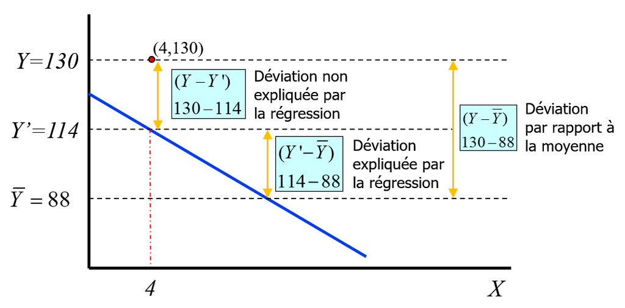

Figure 15.23: Décomposition de la variation d’une variable dépendante

Trois mesures de distance sont construites à partir de ces données:

- $(Y-\overline Y)$: On reconnait cet écart pour sa présence dans la détermination de la variance d’un ensemble de données. Il est à la base de la variance totale de la variable dépendante. En l’élevant au carré et en sommant pour l’ensemble des données, on obtient la **somme des carrés totale**. En divisant cette quantité par $(n-1)$, on obtient la variance de la variable dépendante.

$$SC_{Totale}=\sum\limits_{i=1}^{n}{{(Y-\overline Y)^2}} \tag{15.23}$$

- $(Y-Y')$: la distance entre la valeur observée de Y, et la valeur prédite. On reconnait simplement l’erreur $e_i$, ou valeur résiduelle. On a déjà noté que cet écart est aléatoire, formant la composante stochastique du modèle. En conséquence, rien dans ce modèle ne permet de l’expliquer. La régression ne nous permet pas de le faire. La somme des carrés de cette distance correspond à la **somme des carrés résiduelle**, ou **somme des carrés de l’erreur**:

$$SC_{Résidu}=\sum\limits_{i=1}^{n}{{(Y-Y')^2}} \tag{15.24}$$

- $(Y'-\overline Y)$: La troisième et dernière déviation que l’on peut former est celle entre la valeur prédite de la variable dépendante et la moyenne de cette variable. Elle change avec tout déplacement sur l’axe occupé par la variable indépendante. Connaissant la valeur de X, on peut en déterminer la valeur. Il s’agit d’un écart que l’on peut expliquer par la variable indépendante, ou par la régression. La somme des carrés de cet écart donne la **somme des carrés due à la régression**:

$$SC_{Régression}=\sum\limits_{i=1}^{n}{{(Y'-\overline Y)^2}} \tag{15.25}$$

Les figures Figure 15.24), Figure 15.25), et Figure 15.26), illustrent la nature de ces trois sommes de carrés.

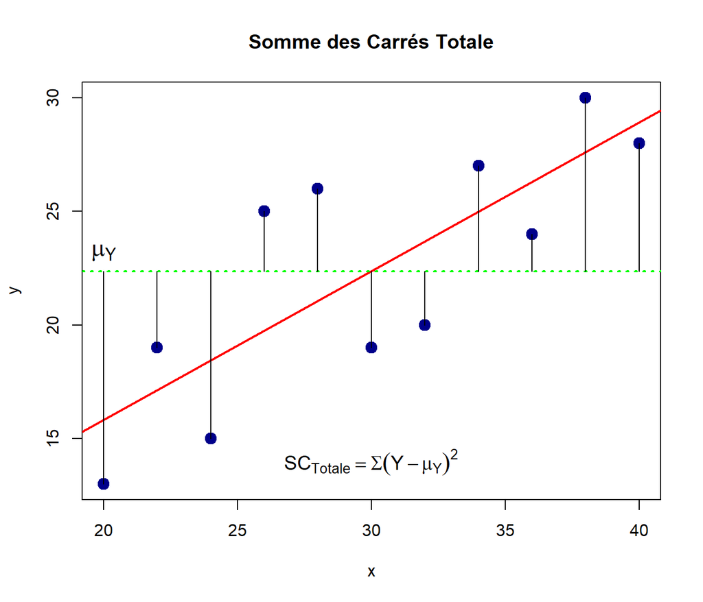

Figure 15.24: Sommes des Carrés Totale.

```r
x <- seq(20, 40, 2)
y <- c(13, 19, 15, 25, 26, 19, 20, 27, 24, 30, 28)
my <- mean(y)
plot(x,y, pch=19, col="darkblue", cex=1.5,
     main="Somme des Carrés Totale")
abline(model <- lm(y~x), lwd=2, col="red")
abline(h=mean(y), lty=3, col="green", lwd=2)
text(20, 23.2, TeX(r'($\mu_Y$)'), cex=1.5)
text(30,14, TeX(r'($SC_{Totale}=\Sigma{(Y-\mu_Y)^2$})'), cex=1.2)
for(i in 1:11){
  segments(x[i], y[i], x[i], my)
}
```

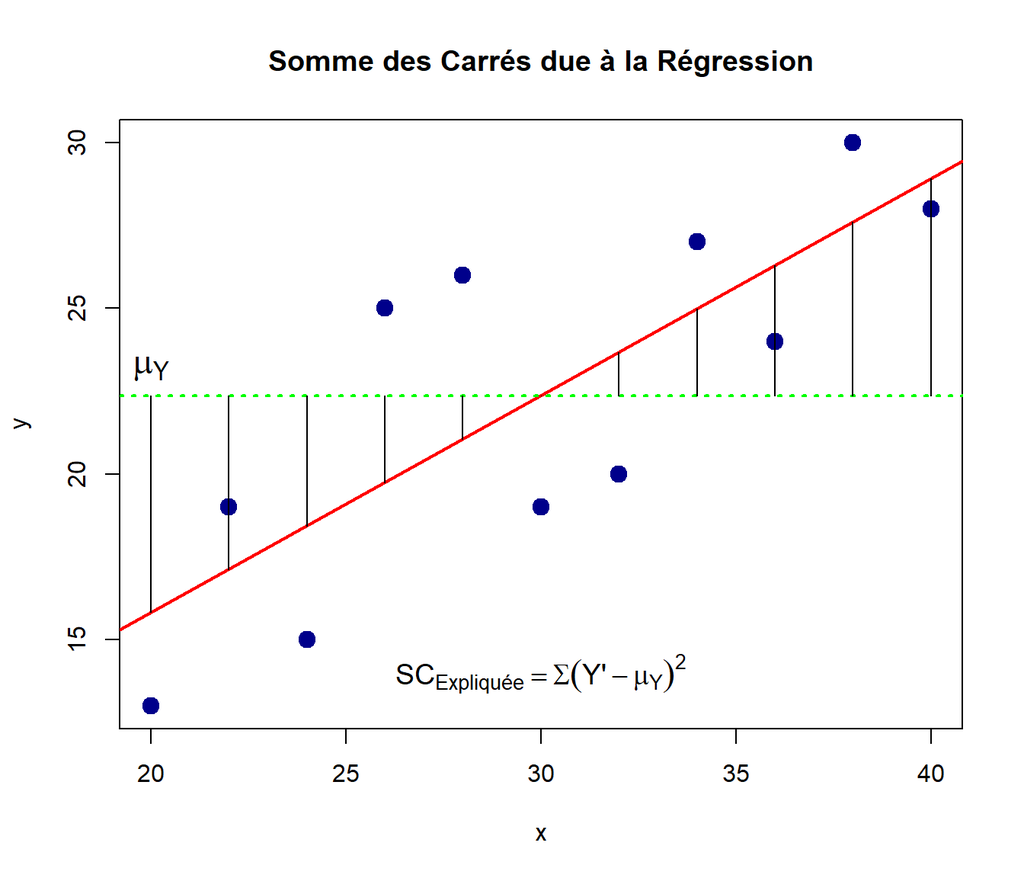

Figure 15.25: Somme des Carrés due à la régression.

```r
x <- seq(20, 40, 2)
y <- c(13, 19, 15, 25, 26, 19, 20, 27, 24, 30, 28)
my <- mean(y)
plot(x,y, pch=19, col="darkblue", cex=1.5,
     main="Somme des Carrés due à la Régression")
abline(model <- lm(y~x), lwd=2, col="red")
yp <- model$fitted.values
abline(h=mean(y), lty=3, col="green", lwd=2)
text(20, 23.2, TeX(r'($\mu_Y$)'), cex=1.5)
text(30,14, TeX(r'($SC_{Expliquée}=\Sigma(Y\'-\mu_Y)^2$)'), cex=1.2)
for(i in 1:11){
  segments(x[i], yp[i], x[i], my)
}
```

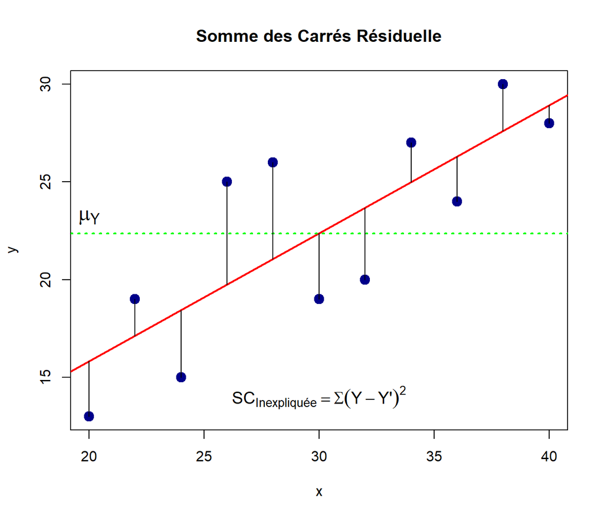

Figure 15.26: Somme des Carrés résiduelle.

```r
x <- seq(20, 40, 2)
y <- c(13, 19, 15, 25, 26, 19, 20, 27, 24, 30, 28)
my <- mean(y)
plot(x,y, pch=19, col="darkblue", cex=1.5,
     main="Somme des Carrés Résiduelle")
abline(model <- lm(y~x), lwd=2, col="red")
yp <- model$fitted.values
abline(h=mean(y), lty=3, col="green", lwd=2)
text(20, 23.2, TeX(r'($\mu_Y$)'), cex=1.5)
text(30, 14, TeX(r'($SC_{Inexpliquée}=\Sigma(Y-Y\')^2$)'), cex=1.2)
for(i in 1:11){
  segments(x[i], y[i], x[i], yp[i])
}
```

Il est important de noter la nature additive de ces sommes de carrés, telle qu’exprimée par l’équation Équation 15.26:

$$SC_{Totale}=SC_{Régression}+SC_{Résidu} \tag{15.26}$$

En termes clairs, la variabilité totale de la variable dépendante comprend deux portions: une portion qui est expliquée par la régression, et une portion qui ne l’est pas. Et il est possible de quantifier chacune d’elles. Cette opération de décomposition de la variance est centrale en analyse quantitative.

#### 15.7.5.1 Exemple numérique

Considérons les données générées par le code R suivant, et les calculs intermédiaires reproduits dans le tableau Table 15.8). Les données ont été générées aléatoirement.

```r
set.seed(150752)
  rho <- 0.5
  n <- 30
  X  <-  rnorm(n)
  Y  <-  rho * X + sqrt(1-rho^2)*rnorm(n)
  X <- as.vector(scale(X) * 8 + 50)
  Y <- as.vector(scale(Y) * 10 + 100)
  r <- cor(X, Y)
  reg <- lm(Y ~ X)
  dd <- data.frame(X , Y, Y-mean(Y), reg$fitted.values, reg$residuals, reg$fitted.values-mean(Y))
  colnames(dd) <- c("X", "Y", "(Y-mY)", "Y'", "(Y-Y')", "(Y'-mY)")
  dd <- rbind(dd, c(mean(X), mean(Y), sum((Y-mean(Y))^2), NA, sum(reg$residuals^2), sum((reg$fitted.values-mean(Y))^2)))
  dd %>%
    kbl(digits=3,
        caption="Données fictives, valeurs prédites et résiduelles", booktabs=TRUE) %>%
    kable_styling(bootstrap_options = c("striped", "hover", "condensed"), full_width=FALSE) %>%
    column_spec(2, bold=FALSE, border_right=TRUE) %>%
    column_spec(1, bold=TRUE, border_left=TRUE, border_right=TRUE) %>%
    row_spec(31, bold=TRUE, background = "yellow")
```

Données fictives, valeurs prédites et résiduelles

| X | Y | (Y-mY) | Y' | (Y-Y') | (Y'-mY) |
| --- | --- | --- | --- | --- | --- |
| 46.417 | 99.316 | -0.684 | 97.444 | 1.872 | -2.556 |
| 46.802 | 93.897 | -6.103 | 97.719 | -3.822 | -2.281 |
| 64.402 | 115.545 | 15.545 | 110.274 | 5.271 | 10.274 |
| 57.134 | 97.587 | -2.413 | 105.089 | -7.502 | 5.089 |
| 45.132 | 92.921 | -7.079 | 96.527 | -3.606 | -3.473 |
| 49.001 | 86.862 | -13.138 | 99.288 | -12.425 | -0.712 |
| 36.078 | 85.644 | -14.356 | 90.068 | -4.424 | -9.932 |
| 55.499 | 101.955 | 1.955 | 103.923 | -1.967 | 3.923 |
| 33.366 | 97.275 | -2.725 | 88.134 | 9.141 | -11.866 |
| 42.124 | 78.552 | -21.448 | 94.382 | -15.829 | -5.618 |
| 58.917 | 125.083 | 25.083 | 106.361 | 18.721 | 6.361 |
| 55.348 | 101.672 | 1.672 | 103.815 | -2.143 | 3.815 |
| 41.782 | 106.142 | 6.142 | 94.137 | 12.004 | -5.863 |
| 61.327 | 103.431 | 3.431 | 108.080 | -4.650 | 8.080 |
| 57.641 | 109.443 | 9.443 | 105.451 | 3.993 | 5.451 |
| 61.044 | 110.774 | 10.774 | 107.879 | 2.896 | 7.879 |
| 48.563 | 94.247 | -5.753 | 98.975 | -4.728 | -1.025 |
| 61.923 | 110.291 | 10.291 | 108.506 | 1.785 | 8.506 |
| 49.022 | 114.892 | 14.892 | 99.302 | 15.590 | -0.698 |
| 38.462 | 94.838 | -5.162 | 91.769 | 3.069 | -8.231 |
| 38.048 | 94.500 | -5.500 | 91.474 | 3.027 | -8.526 |
| 50.345 | 106.233 | 6.233 | 100.246 | 5.987 | 0.246 |
| 50.272 | 93.235 | -6.765 | 100.194 | -6.959 | 0.194 |
| 53.024 | 106.595 | 6.595 | 102.157 | 4.438 | 2.157 |
| 53.095 | 85.031 | -14.969 | 102.208 | -17.176 | 2.208 |
| 53.726 | 97.259 | -2.741 | 102.658 | -5.400 | 2.658 |
| 52.388 | 96.956 | -3.044 | 101.703 | -4.747 | 1.703 |
| 46.435 | 98.900 | -1.100 | 97.457 | 1.443 | -2.543 |
| 47.696 | 104.920 | 4.920 | 98.356 | 6.564 | -1.644 |
| 44.988 | 96.002 | -3.998 | 96.424 | -0.422 | -3.576 |
| 50.000 | 100.000 | 2900.000 |  | 1955.461 | 944.539 |

Table 15.8: Relation entre deux variables, X et Y. Dans ce tableau, mY est la moyenne de la variable dépendante. La dernière ligne affiche les moyennes de X et de Y, SCtot, SCrésidu et SCrég.

La figure Figure 15.27 affiche le diagramme de dispersion correspondant aux données du tableau Table 15.8:

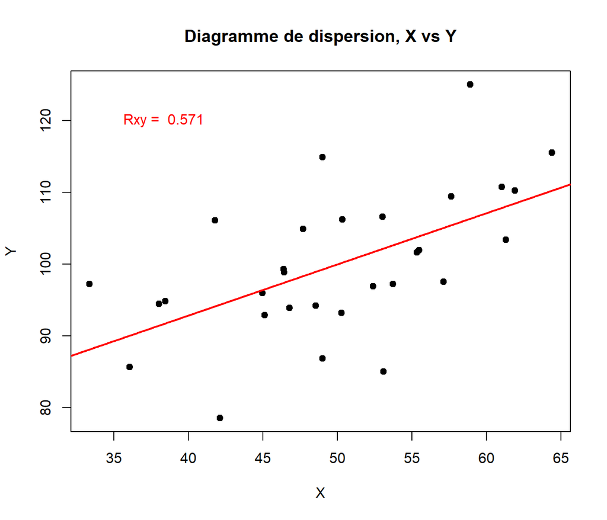

Figure 15.27: Diagramme de dispersion des données du tableau Table 15.8.

```r
plot(X, Y, main="Diagramme de dispersion, X vs Y", pch=19)
  text(min(X)+5, max(Y)-5,
       paste("Rxy = ", round(r ,3)),
       col = "red")
  abline(reg, col="red", lwd=2)
  aov <- anova(reg)
  SCtot <- (length(Y)-1) * var(Y)
  SCreg <- aov$`Sum Sq`[1]
  SCres <- aov$`Sum Sq`[2]
```

L’analyse de la régression de X sur Y produit les résultats suivants:

```r
summary(reg)
```

```
#>
#> Call:
#> lm(formula = Y ~ X)
#>
#> Residuals:
#>      Min       1Q   Median       3Q      Max
#> -17.1764  -4.7086   0.5106   4.3265  18.7210
#>
#> Coefficients:
#>             Estimate Std. Error t value Pr(>|t|)
#> (Intercept)  64.3310     9.8183   6.552  4.2e-07 ***
#> X             0.7134     0.1940   3.678  0.00099 ***
#> ---
#> Signif. codes:  0 '***' 0.001 '**' 0.01 '*' 0.05 '.' 0.1 ' ' 1
#>
#> Residual standard error: 8.357 on 28 degrees of freedom
#> Multiple R-squared:  0.3257, Adjusted R-squared:  0.3016
#> F-statistic: 13.52 on 1 and 28 DF,  p-value: 0.0009903
```

```r
anova(reg)
```

```
#> Analysis of Variance Table
#>
#> Response: Y
#>           Df  Sum Sq Mean Sq F value    Pr(>F)
#> X          1  944.54  944.54  13.525 0.0009903 ***
#> Residuals 28 1955.46   69.84
#> ---
#> Signif. codes:  0 '***' 0.001 '**' 0.01 '*' 0.05 '.' 0.1 ' ' 1
```

L’équation de régression liant Y à X est donc:

```r
equatiomatic::extract_eq(reg,
                         use_coefs = TRUE,
                          se_subscripts = TRUE)
```

$$\operatorname{\widehat{Y}} = \underset{(9.818)}{64.33} + \underset{(0.194)}{0.71(\operatorname{X})}$$

La variance de la variable dépendante (Y) est égale à:

```r
cat("Var(Y) = ", VarY <- var(Y))
```

```
#> Var(Y) =  100
```

de sorte que la somme des carrés totale est $SC_{Totale}=(n-1)s_Y^2=29\times 100=2900$, tel qu’affiché à la dernière ligne, troisième colonne du tableau Table 15.8). Il s’agit d’une mesure de la variabilité totale de la variable dépendante, celle-là même que l’on tente d’expliquer. Cette quantité se décompose en deux parties:

- $SC_{Résiduelle}=1955.461$: Cette quantité correspond à la portion de la somme des carrés totale que l’on ne peut pas expliquer en terme de la variable indépendante. C’est une composante aléatoire qui, éventuellement, pourrait être décomposée en termes de facteurs autres que la variable indépendante (par l’ajout d’autres variables dans le modèle, comme on le verra dans un chapitre ultérieur).
- $SC_{Régression}=944.539$: Cette quantité correspond à la portion de $SC_{Totale}$ que l’on peut expliquer en terme de la variable indépendante. Sa valeur augmente en fonction de l’importance de la relation entre les deux variables.

Sous R, on obtient des quantités aisément en utilisant les fonctions **residuals()** et **predict()**, appliquées sur le résultat d’une régression (**lm()**):

```r
reg <- lm(Y ~ X)
SCres <- sum(residuals(reg)^2)
SCreg <- sum((predict(reg) - mean(Y))^2)

cat("SCreg = ", round(SCreg, 3))
```

```
#> SCreg =  944.539
```

```r
cat("SCres = ", round(SCres, 3))
```

```
#> SCres =  1955.461
```

```r
cat("SCtot = ", round(SCreg + SCres, 3))
```

```
#> SCtot =  2900
```

Puisque les composantes de la variation totale sont additives, on peut exprimer $SC_{Régression}$ et $SC_{Résidu}$ en termes de proportions de la variation totale. Graphiquement, la figure Figure 15.28 résume la situation:

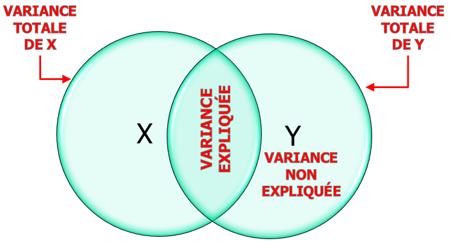

Figure 15.28: Décomposition de la variance

Dans cette figure, la variance de chacune des variables est représente par un cercle. Plus la relation entre X et Y est forte, plus l’intersection prend de l’importance. Cette intersection représente la portion de la variance de Y qui peut s’expliquer par X. La portion de Y que X ne recouvre pas correspond à la variance qui demeure inexpliquée par le modèle. En bref, la régression permet d’expliquer une portion, grande ou petite selon le degré de relation entre les variables, de la variance de la variable dépendante. La portion qui demeure inexpliquée regroupe les influences d’autres facteurs ne faisant pas partie du modèle.

### 15.7.6 Le coefficient de détermination

Puisque les composantes de la variation totale sont additives, on peut les exprimer en termes de proportions. Formellement, le rapport entre $SC_{Régression}$ et $SC_{Totale}$ représentera la proportion de la variation totale expliquée par la variable indépendante. Ce rapport est le **coefficient de détermination**, un indice statistique omniprésent en méthodologie quantitative. Il prend évidemment une valeur comprise entre 0 (absence de relation) et 1 (relation parfaite). Fait à noter, sa valeur est simplement le carré du coefficient de corrélation. Formellement, il est défini par l’équation Équation 15.27:

$$r^2=\frac{SC_{Régression}}{SC_{Totale}}= \frac{SC_{Totale}-SC_{Résidu}}{SC_{Totale}} \tag{15.27}$$

Pour l’exemple précédent, on trouve:

$$r^2=\frac{944.539}{2900}=\frac{2900-1955.461}{2900} =0.3257$$
On peut donc affirmer que 32.57% de la variabilité de Y est imputable à la variable indépendante. Il reste 67.43% de cette variabilité à expliquer.

L’équation Équation 15.28 présente une formulation alternative du coefficient de détermination faisant appel aux variances plutôt qu’aux sommes de carrés:

$$r^2=1-\frac{CM_{Résidu}}{s_Y^2} \tag{15.28}$$

Tous les outils informatiques rapportent cette quantité dès qu’il s’agit d’un modèle de régression linéaire. Il est facile de se laisser prendre au jeu et de donner trop d’importance au $r^2$, en lui attribuant un rôle qu’il n’a pas dans l’évaluation de la qualité de l’ajustement. En effet, peu importe sa valeur (sauf $r^2=1$, dénotant une relation parfaite), $r^2$ ne nous permet pas de juger de l’ajustement d’un modèle. Il nous indique jusqu’à quel point le modèle permet d’expliquer les données. Mais dans beaucoup de situation, on a besoin d’en savoir plus sur la capacité du modèle à prédire les données futures. Le $r^2$ est utile dans un contexte d’**explication**, mais n’est pas très éloquent dans un contexte de **prédiction**.

L’ensemble de données de Anscombe [Anscombe, F. J. (1973), *Graphs in Statistical Analysis*, American Statistician, 27 (1): 17–21] démontre ce simple fait de manière éloquente. Considérons le **Quartet de Anscombe**, formé des données reproduites dans le tableau Table 15.9). Pour chacun des Quartets, le tableau Table 15.10) présente les statistiques descriptives habituelles: on note la quasi-égalité de tous les indices rapportés.

```r
Anscombe <- matrix(c(10.0,  8.04,   10.0,   9.14,   10.0,   7.46,   8.0,    6.58,
8.0,    6.95,   8.0,    8.14,   8.0,    6.77,   8.0,    5.76,
13.0,   7.58,   13.0,   8.74,   13.0,   12.74,  8.0,    7.71,
9.0,    8.81,   9.0,    8.77,   9.0,    7.11,   8.0,    8.84,
11.0,   8.33,   11.0,   9.26,   11.0,   7.81,   8.0,    8.47,
14.0,   9.96,   14.0,   8.10,   14.0,   8.84,   8.0,    7.04,
6.0,    7.24,   6.0,    6.13,   6.0,    6.08,   8.0,    5.25,
4.0,    4.26,   4.0, 3.10,  4.0,    5.39,   19.0,   12.50,
12.0,   10.84,  12.0,   9.13,   12.0,   8.15,   8.0,    5.56,
7.0,    4.82,   7.0,    7.26,   7.0,    6.42,   8.0,    7.91,
5.0,    5.68,   5.0,    4.74,   5.0,    5.73,   8.0,    6.89), nrow=11, byrow=TRUE)
colnames(Anscombe) <- c("x1", "y1", "x2", "y2", "x3", "y3", "x4", "y4")
Anscombe %>%
    kbl(digits=3, booktabs=TRUE) %>%
    kable_styling(bootstrap_options = c("striped", "hover", "condensed"), full_width=FALSE) %>%
    column_spec(1, bold=FALSE, border_left=TRUE) %>%
    column_spec(2, bold=FALSE, border_right=TRUE) %>%
    column_spec(4, bold=FALSE, border_right=TRUE) %>%
    column_spec(6, bold=FALSE, border_right=TRUE) %>%
    column_spec(8, bold=FALSE, border_right=TRUE) %>%
    row_spec(0, bold=TRUE, background = "#7FFFD0") %>%
    add_header_above(c("Quartet I"=2, "Quartet II"=2, "Quartet III"=2, "Quartet IV"=2))
```

Table 15.9: Quartets de Anscombe, illustrant l’incapacité du coefficient de détermination à rendre compte de l’ajustement d’un modèle.

| Quartet I x1 | Quartet I y1 | Quartet II x2 | Quartet II y2 | Quartet III x3 | Quartet III y3 | Quartet IV x4 | Quartet IV y4 |
| --- | --- | --- | --- | --- | --- | --- | --- |
| 10 | 8.04 | 10 | 9.14 | 10 | 7.46 | 8 | 6.58 |
| 8 | 6.95 | 8 | 8.14 | 8 | 6.77 | 8 | 5.76 |
| 13 | 7.58 | 13 | 8.74 | 13 | 12.74 | 8 | 7.71 |
| 9 | 8.81 | 9 | 8.77 | 9 | 7.11 | 8 | 8.84 |
| 11 | 8.33 | 11 | 9.26 | 11 | 7.81 | 8 | 8.47 |
| 14 | 9.96 | 14 | 8.10 | 14 | 8.84 | 8 | 7.04 |
| 6 | 7.24 | 6 | 6.13 | 6 | 6.08 | 8 | 5.25 |
| 4 | 4.26 | 4 | 3.10 | 4 | 5.39 | 19 | 12.50 |
| 12 | 10.84 | 12 | 9.13 | 12 | 8.15 | 8 | 5.56 |
| 7 | 4.82 | 7 | 7.26 | 7 | 6.42 | 8 | 7.91 |
| 5 | 5.68 | 5 | 4.74 | 5 | 5.73 | 8 | 6.89 |

Ces 4 ensembles de données sont très différents, mais leurs statistiques sont essentiellement les mêmes, tel qu’illustré dans le tableau Table 15.10

```r
meanAns <- colMeans(Anscombe)
varAns <- Rfast::colVars(Anscombe)
corAns <- c(cor(Anscombe[,1], Anscombe[,2]),
          cor(Anscombe[,3], Anscombe[,4]),
          cor(Anscombe[,5], Anscombe[,6]),
          cor(Anscombe[,7], Anscombe[,8]))
regAns <- c(lm(Anscombe[,2]~Anscombe[,1])$coefficients,
            lm(Anscombe[,4]~Anscombe[,3])$coefficients,
            lm(Anscombe[,6]~Anscombe[,5])$coefficients,
            lm(Anscombe[,8]~Anscombe[,7])$coefficients)
res <- data.frame(meanAns[c(1,3,5,7)], meanAns[c(2,4,6,8)],
                  varAns[c(1,3,5,7)], varAns[c(2,4,6,8)],
                  corAns,
                  corAns^2,
                  regAns[c(1,3,5,7)],
                  regAns[c(2,4,6,8)])
rownames(res) <- c("Quartet I", "Quartet II", "Quartet III", "Quartet IV")
colnames(res) <- c("Moyenne X", "Moyenne Y", "Var(X)", "Var(Y)", "Corr", "R2", "b0", "b1" )

res %>%
    kbl(digits=3, booktabs=TRUE) %>%
    kable_styling(bootstrap_options = c("striped", "hover", "condensed"), full_width=FALSE) %>%
    column_spec(1, bold=FALSE, border_left=TRUE) %>%
    column_spec(2, bold=FALSE, border_right=FALSE) %>%
    column_spec(4, bold=FALSE, border_right=FALSE) %>%
    column_spec(6, bold=FALSE, border_right=FALSE) %>%
    column_spec(9, bold=FALSE, border_right=TRUE) %>%
    row_spec(0, bold=TRUE, background = "#7FFFD0")
```

Table 15.10: Statistiques descriptives pour les quartets de Anscombe.

|  | Moyenne X | Moyenne Y | Var(X) | Var(Y) | Corr | R2 | b0 | b1 |
| --- | --- | --- | --- | --- | --- | --- | --- | --- |
| Quartet I | 9 | 7.501 | 11 | 4.127 | 0.816 | 0.667 | 3.000 | 0.5 |
| Quartet II | 9 | 7.501 | 11 | 4.128 | 0.816 | 0.666 | 3.001 | 0.5 |
| Quartet III | 9 | 7.500 | 11 | 4.123 | 0.816 | 0.666 | 3.002 | 0.5 |
| Quartet IV | 9 | 7.501 | 11 | 4.123 | 0.817 | 0.667 | 3.002 | 0.5 |

Les figures Figure 15.29, Figure 15.30, Figure 15.31 et Figure 15.32 illustrent la défaillance du coefficient de détermination dans un rôle d’évaluation de la qualité de l’ajustement.

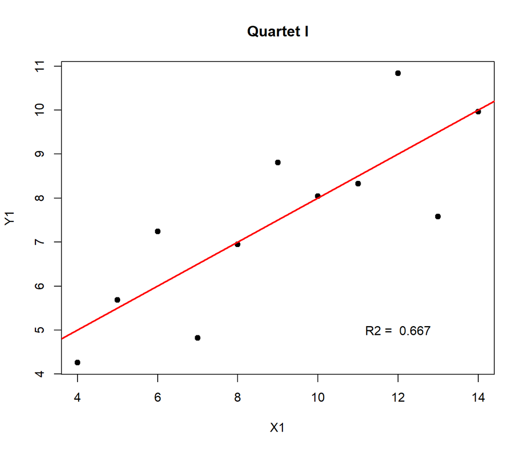

Figure 15.29: Quartet I.

```r
plot(Anscombe[,1], Anscombe[,2],
     pch=19,
     xlab="X1",
     ylab="Y1",
     main="Quartet I")
abline(lm(Anscombe[,2]~Anscombe[,1]),
       col="red", lwd=2)
text(12, 5, paste("R2 = ", round(corAns[1]^2, 3)))
```

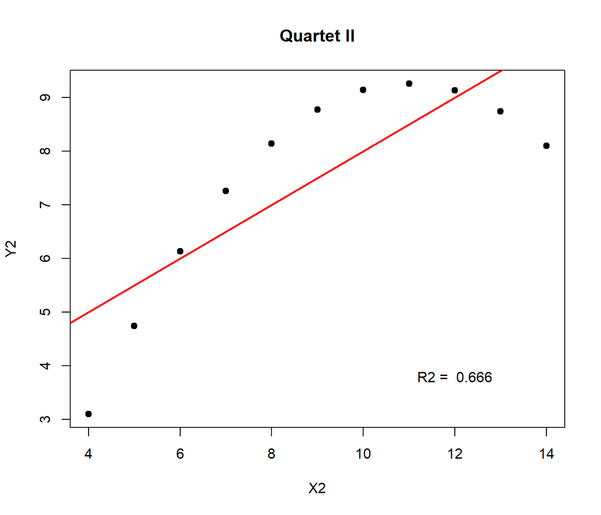

Figure 15.30: Quartet II.

```r
plot(Anscombe[,3], Anscombe[,4],
     pch=19,
     xlab="X2",
     ylab="Y2",
     main="Quartet II")
abline(lm(Anscombe[,4]~Anscombe[,3]),
       col="red", lwd=2)
text(12, 3.8, paste("R2 = ", round(corAns[2]^2, 3)))
```

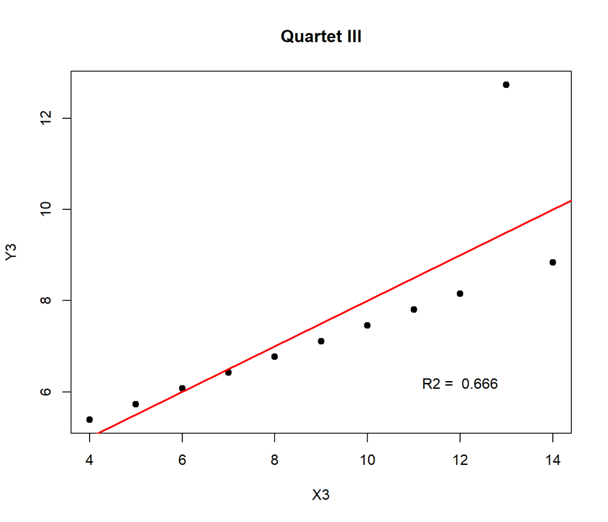

Figure 15.31: Quartet III.

```r
plot(Anscombe[,5], Anscombe[,6],
     pch=19,
     xlab="X3",
     ylab="Y3",
     main="Quartet III")
abline(lm(Anscombe[,6]~Anscombe[,5]),
       col="red", lwd=2)
text(12, 6.2, paste("R2 = ", round(corAns[3]^2, 3)))
```

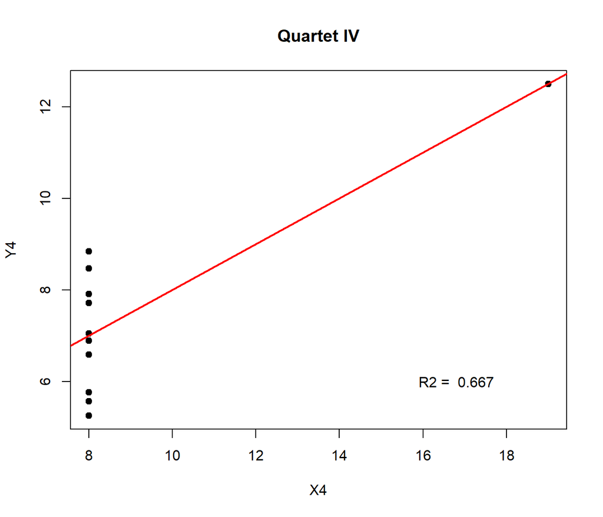

Figure 15.32: Quartet IV.

```r
plot(Anscombe[,7], Anscombe[,8],
     pch=19,
     xlab="X4",
     ylab="Y4",
     main="Quartet IV")
abline(lm(Anscombe[,8]~Anscombe[,7]),
       col="red", lwd=2)
text(16.8, 6, paste("R2 = ", round(corAns[4]^2, 3)))
```

Cette expérience démontre sans équivoque que le coefficient de détermination n’est en rien un indicateur de la qualité de l’ajustement. Si c’était le cas, sa valeur serait élevée pour le Quartet I (Figure Figure 15.29)), et plus faible pour le Quartet II (Figure Figure 15.30)). Pour le Quartet III (Figure Figure 15.31)), l’imperfection de la relation n’est due qu’à un seul point, tous les autres s’alignant sur une droite. Finalement, toute la valeur du $r^2$ pour le Quartet IV (Figure 15.32) n’est due qu’à un seul point, la relation n’existant pas autrement.

Si le coefficient de détermination était un indice de la qualité de l’ajustement, il devrait avoir une valeur plus élevée pour le Quartet I que pour les trois autres. Or, ce n’est pas le cas: peu importe la configuration des points dans les quatre diagrammes, on obtient $r^2 = 0.667$. En conséquence, on aura éventuellement besoin de mesures plus fiables pour évaluer la qualité de l’ajustement. Le coefficient de détermination ne peut remplir ce rôle.

D’autres formes de coefficients de détermination trouvent des applications dans un contexte de régression multiple, lorsque plusieurs variables indépendantes sont intégrées dans un modèle. Nous y reviendrons donc dans le chapitre suivant.